# Project: Identify Customer Segments

In this project, you will apply unsupervised learning techniques to identify segments of the population that form the core customer base for a mail-order sales company in Germany. These segments can then be used to direct marketing campaigns towards audiences that will have the highest expected rate of returns. The data that you will use has been provided by our partners at Bertelsmann Arvato Analytics, and represents a real-life data science task.

This notebook will help you complete this task by providing a framework within which you will perform your analysis steps. In each step of the project, you will see some text describing the subtask that you will perform, followed by one or more code cells for you to complete your work. **Feel free to add additional code and markdown cells as you go along so that you can explore everything in precise chunks.** The code cells provided in the base template will outline only the major tasks, and will usually not be enough to cover all of the minor tasks that comprise it.

It should be noted that while there will be precise guidelines on how you should handle certain tasks in the project, there will also be places where an exact specification is not provided. **There will be times in the project where you will need to make and justify your own decisions on how to treat the data.** These are places where there may not be only one way to handle the data. In real-life tasks, there may be many valid ways to approach an analysis task. One of the most important things you can do is clearly document your approach so that other scientists can understand the decisions you've made.

At the end of most sections, there will be a Markdown cell labeled **Discussion**. In these cells, you will report your findings for the completed section, as well as document the decisions that you made in your approach to each subtask. **Your project will be evaluated not just on the code used to complete the tasks outlined, but also your communication about your observations and conclusions at each stage.**

```python
# import libraries here; add more as necessary
import numpy as np
import pandas as pd
import matplotlib.pyplot as plt
import seaborn as sns
import helpers as hlp
from tqdm import tqdm
from sklearn.decomposition import PCA
from sklearn.cluster import KMeans, MiniBatchKMeans
from sklearn.preprocessing import StandardScaler
from sklearn.preprocessing import Imputer

# magic word for producing visualizations in notebook
%matplotlib inline
plt.rc("axes", grid=True)
plt.rc("grid", alpha=0.3)
'''
Import note: The classroom currently uses sklearn version 0.19.
If you need to use an imputer, it is available in sklearn.preprocessing.Imputer,
instead of sklearn.impute as in newer versions of sklearn.
'''
```

```
'\nImport note: The classroom currently uses sklearn version 0.19.\nIf you need to use an imputer, it is available in sklearn.preprocessing.Imputer,\ninstead of sklearn.impute as in newer versions of sklearn.\n'
```

### Step 0: Load the Data

Each row of the demographics files represents a single person, but also includes information outside of individuals, including information about their household, building, and neighborhood. You will use this information to cluster the general population into groups with similar demographic properties. Then, you will see how the people in the customers dataset fit into those created clusters. The hope here is that certain clusters are over-represented in the customers data, as compared to the general population; those over-represented clusters will be assumed to be part of the core userbase. This information can then be used for further applications, such as targeting for a marketing campaign.

To start off with, load in the demographics data for the general population into a pandas DataFrame, and do the same for the feature attributes summary. Note for all of the `.csv` data files in this project: they're semicolon (`;`) delimited, so you'll need an additional argument in your [`read_csv()`](https://pandas.pydata.org/pandas-docs/stable/generated/pandas.read_csv.html) call to read in the data properly. Also, considering the size of the main dataset, it may take some time for it to load completely.

Once the dataset is loaded, it's recommended that you take a little bit of time just browsing the general structure of the dataset and feature summary file. You'll be getting deep into the innards of the cleaning in the first major step of the project, so gaining some general familiarity can help you get your bearings.

```python
# Load in the general demographics data.
azdias = pd.read_csv("Udacity_AZDIAS_Subset.csv", sep=";")

# Load in the feature summary file.
feat_info = pd.read_csv("AZDIAS_Feature_Summary.csv", sep=";")
```

```python
# Check the structure of the data after it's loaded (e.g. print the number of
# rows and columns, print the first few rows).
print(f"- for the general demographics dataset, there are {azdias.shape[0]} rows and {azdias.shape[1]} columns")
print(f"- for the feature attributes summary dataset, there are {feat_info.shape[0]} rows and {feat_info.shape[1]} columns")
```

```
- for the general demographics dataset, there are 891221 rows and 85 columns
- for the feature attributes summary dataset, there are 85 rows and 4 columns
```

```python
azdias.head()
```

|  | AGER_TYP | ALTERSKATEGORIE_GROB | ANREDE_KZ | CJT_GESAMTTYP | FINANZ_MINIMALIST | FINANZ_SPARER | FINANZ_VORSORGER | FINANZ_ANLEGER | FINANZ_UNAUFFAELLIGER | FINANZ_HAUSBAUER | ... | PLZ8_ANTG1 | PLZ8_ANTG2 | PLZ8_ANTG3 | PLZ8_ANTG4 | PLZ8_BAUMAX | PLZ8_HHZ | PLZ8_GBZ | ARBEIT | ORTSGR_KLS9 | RELAT_AB |
| --- | --- | --- | --- | --- | --- | --- | --- | --- | --- | --- | --- | --- | --- | --- | --- | --- | --- | --- | --- | --- | --- |
| 0 | -1 | 2 | 1 | 2.0 | 3 | 4 | 3 | 5 | 5 | 3 | ... | NaN | NaN | NaN | NaN | NaN | NaN | NaN | NaN | NaN | NaN |
| 1 | -1 | 1 | 2 | 5.0 | 1 | 5 | 2 | 5 | 4 | 5 | ... | 2.0 | 3.0 | 2.0 | 1.0 | 1.0 | 5.0 | 4.0 | 3.0 | 5.0 | 4.0 |
| 2 | -1 | 3 | 2 | 3.0 | 1 | 4 | 1 | 2 | 3 | 5 | ... | 3.0 | 3.0 | 1.0 | 0.0 | 1.0 | 4.0 | 4.0 | 3.0 | 5.0 | 2.0 |
| 3 | 2 | 4 | 2 | 2.0 | 4 | 2 | 5 | 2 | 1 | 2 | ... | 2.0 | 2.0 | 2.0 | 0.0 | 1.0 | 3.0 | 4.0 | 2.0 | 3.0 | 3.0 |
| 4 | -1 | 3 | 1 | 5.0 | 4 | 3 | 4 | 1 | 3 | 2 | ... | 2.0 | 4.0 | 2.0 | 1.0 | 2.0 | 3.0 | 3.0 | 4.0 | 6.0 | 5.0 |

5 rows × 85 columns

```python
feat_info.head()
```

|  | attribute | information_level | type | missing_or_unknown |
| --- | --- | --- | --- | --- |
| 0 | AGER_TYP | person | categorical | [-1,0] |
| 1 | ALTERSKATEGORIE_GROB | person | ordinal | [-1,0,9] |
| 2 | ANREDE_KZ | person | categorical | [-1,0] |
| 3 | CJT_GESAMTTYP | person | categorical | [0] |
| 4 | FINANZ_MINIMALIST | person | ordinal | [-1] |

```python
azdias.info()
```

```
<class 'pandas.core.frame.DataFrame'>
RangeIndex: 891221 entries, 0 to 891220
Data columns (total 85 columns):
AGER_TYP                 891221 non-null int64
ALTERSKATEGORIE_GROB     891221 non-null int64
ANREDE_KZ                891221 non-null int64
CJT_GESAMTTYP            886367 non-null float64
FINANZ_MINIMALIST        891221 non-null int64
FINANZ_SPARER            891221 non-null int64
FINANZ_VORSORGER         891221 non-null int64
FINANZ_ANLEGER           891221 non-null int64
FINANZ_UNAUFFAELLIGER    891221 non-null int64
FINANZ_HAUSBAUER         891221 non-null int64
FINANZTYP                891221 non-null int64
GEBURTSJAHR              891221 non-null int64
GFK_URLAUBERTYP          886367 non-null float64
GREEN_AVANTGARDE         891221 non-null int64
HEALTH_TYP               891221 non-null int64
LP_LEBENSPHASE_FEIN      886367 non-null float64
LP_LEBENSPHASE_GROB      886367 non-null float64
LP_FAMILIE_FEIN          886367 non-null float64
LP_FAMILIE_GROB          886367 non-null float64
LP_STATUS_FEIN           886367 non-null float64
LP_STATUS_GROB           886367 non-null float64
NATIONALITAET_KZ         891221 non-null int64
PRAEGENDE_JUGENDJAHRE    891221 non-null int64
RETOURTYP_BK_S           886367 non-null float64
SEMIO_SOZ                891221 non-null int64
SEMIO_FAM                891221 non-null int64
SEMIO_REL                891221 non-null int64
SEMIO_MAT                891221 non-null int64
SEMIO_VERT               891221 non-null int64
SEMIO_LUST               891221 non-null int64
SEMIO_ERL                891221 non-null int64
SEMIO_KULT               891221 non-null int64
SEMIO_RAT                891221 non-null int64
SEMIO_KRIT               891221 non-null int64
SEMIO_DOM                891221 non-null int64
SEMIO_KAEM               891221 non-null int64
SEMIO_PFLICHT            891221 non-null int64
```

[output cut: 35 more lines]

```
ONLINE_AFFINITAET        886367 non-null float64
REGIOTYP                 770025 non-null float64
KBA13_ANZAHL_PKW         785421 non-null float64
PLZ8_ANTG1               774706 non-null float64
PLZ8_ANTG2               774706 non-null float64
PLZ8_ANTG3               774706 non-null float64
PLZ8_ANTG4               774706 non-null float64
PLZ8_BAUMAX              774706 non-null float64
PLZ8_HHZ                 774706 non-null float64
PLZ8_GBZ                 774706 non-null float64
ARBEIT                   794005 non-null float64
ORTSGR_KLS9              794005 non-null float64
RELAT_AB                 794005 non-null float64
dtypes: float64(49), int64(32), object(4)
memory usage: 578.0+ MB
```

```python
feat_info.info()
```

```
<class 'pandas.core.frame.DataFrame'>
RangeIndex: 85 entries, 0 to 84
Data columns (total 4 columns):
attribute             85 non-null object
information_level     85 non-null object
type                  85 non-null object
missing_or_unknown    85 non-null object
dtypes: object(4)
memory usage: 2.7+ KB
```

```python
azdias.select_dtypes(include = 'float').describe().T.style.background_gradient(cmap = 'RdPu')
```

|  | count | mean | std | min | 25% | 50% | 75% | max |
| --- | --- | --- | --- | --- | --- | --- | --- | --- |
| CJT_GESAMTTYP | 886367 | 3.63284 | 1.59502 | 1 | 2 | 4 | 5 | 6 |
| GFK_URLAUBERTYP | 886367 | 7.3503 | 3.52572 | 1 | 5 | 8 | 10 | 12 |
| LP_LEBENSPHASE_FEIN | 886367 | 14.6226 | 12.6169 | 0 | 4 | 11 | 27 | 40 |
| LP_LEBENSPHASE_GROB | 886367 | 4.45362 | 3.85564 | 0 | 1 | 3 | 8 | 12 |
| LP_FAMILIE_FEIN | 886367 | 3.59957 | 3.92649 | 0 | 1 | 1 | 8 | 11 |
| LP_FAMILIE_GROB | 886367 | 2.18597 | 1.75654 | 0 | 1 | 1 | 4 | 5 |
| LP_STATUS_FEIN | 886367 | 4.79115 | 3.42531 | 1 | 2 | 4 | 9 | 10 |
| LP_STATUS_GROB | 886367 | 2.43257 | 1.47431 | 1 | 1 | 2 | 4 | 5 |
| RETOURTYP_BK_S | 886367 | 3.41963 | 1.41774 | 1 | 2 | 3 | 5 | 5 |
| SOHO_KZ | 817722 | 0.0084234 | 0.0913918 | 0 | 0 | 0 | 0 | 1 |
| TITEL_KZ | 817722 | 0.00348285 | 0.0849572 | 0 | 0 | 0 | 0 | 5 |
| ALTER_HH | 817722 | 10.8641 | 7.63968 | 0 | 0 | 13 | 17 | 21 |
| ANZ_PERSONEN | 817722 | 1.72764 | 1.15585 | 0 | 1 | 1 | 2 | 45 |
| ANZ_TITEL | 817722 | 0.00416156 | 0.0688551 | 0 | 0 | 0 | 0 | 6 |
| HH_EINKOMMEN_SCORE | 872873 | 4.20724 | 1.62406 | 1 | 3 | 5 | 6 | 6 |
| KK_KUNDENTYP | 306609 | 3.41064 | 1.62884 | 1 | 2 | 3 | 5 | 6 |
| W_KEIT_KIND_HH | 783619 | 3.93341 | 1.9647 | 0 | 2 | 4 | 6 | 6 |
| WOHNDAUER_2008 | 817722 | 7.90879 | 1.92314 | 1 | 8 | 9 | 9 | 9 |
| ANZ_HAUSHALTE_AKTIV | 798073 | 8.28726 | 15.6281 | 0 | 1 | 4 | 9 | 595 |
| ANZ_HH_TITEL | 794213 | 0.0406465 | 0.324028 | 0 | 0 | 0 | 0 | 23 |
| GEBAEUDETYP | 798073 | 2.79864 | 2.65671 | 1 | 1 | 1 | 3 | 8 |
| KONSUMNAEHE | 817252 | 3.01845 | 1.55031 | 1 | 2 | 3 | 4 | 7 |
| MIN_GEBAEUDEJAHR | 798073 | 1993.28 | 3.33274 | 1985 | 1992 | 1992 | 1993 | 2016 |
| WOHNLAGE | 798073 | 4.05284 | 1.94954 | 0 | 3 | 3 | 5 | 8 |
| KBA05_ANTG1 | 757897 | 1.49428 | 1.40396 | 0 | 0 | 1 | 3 | 4 |
| KBA05_ANTG2 | 757897 | 1.26558 | 1.24518 | 0 | 0 | 1 | 2 | 4 |
| KBA05_ANTG3 | 757897 | 0.624525 | 1.01344 | 0 | 0 | 0 | 1 | 3 |
| KBA05_ANTG4 | 757897 | 0.305927 | 0.638725 | 0 | 0 | 0 | 0 | 2 |
| KBA05_BAUMAX | 757897 | 1.38955 | 1.77948 | 0 | 0 | 1 | 3 | 5 |
| KBA05_GBZ | 757897 | 3.15858 | 1.32954 | 1 | 2 | 3 | 4 | 5 |
| BALLRAUM | 797481 | 4.15304 | 2.18371 | 1 | 2 | 5 | 6 | 7 |
| EWDICHTE | 797481 | 3.93917 | 1.719 | 1 | 2 | 4 | 6 | 6 |
| INNENSTADT | 797481 | 4.54949 | 2.02892 | 1 | 3 | 5 | 6 | 8 |
| GEBAEUDETYP_RASTER | 798066 | 3.73831 | 0.923193 | 1 | 3 | 4 | 4 | 5 |
| KKK | 770025 | 2.59299 | 1.11905 | 0 | 2 | 3 | 3 | 4 |
| MOBI_REGIO | 757897 | 2.96354 | 1.42888 | 1 | 2 | 3 | 4 | 6 |
| ONLINE_AFFINITAET | 886367 | 2.69869 | 1.52152 | 0 | 1 | 3 | 4 | 5 |
| REGIOTYP | 770025 | 4.25797 | 2.03038 | 0 | 3 | 5 | 6 | 7 |
| KBA13_ANZAHL_PKW | 785421 | 619.701 | 340.034 | 0 | 384 | 549 | 778 | 2300 |
| PLZ8_ANTG1 | 774706 | 2.25333 | 0.972008 | 0 | 1 | 2 | 3 | 4 |
| PLZ8_ANTG2 | 774706 | 2.80186 | 0.920309 | 0 | 2 | 3 | 3 | 4 |
| PLZ8_ANTG3 | 774706 | 1.59543 | 0.986736 | 0 | 1 | 2 | 2 | 3 |
| PLZ8_ANTG4 | 774706 | 0.699166 | 0.727137 | 0 | 0 | 1 | 1 | 2 |
| PLZ8_BAUMAX | 774706 | 1.94391 | 1.45965 | 1 | 1 | 1 | 3 | 5 |
| PLZ8_HHZ | 774706 | 3.61282 | 0.973967 | 1 | 3 | 4 | 4 | 5 |
| PLZ8_GBZ | 774706 | 3.38109 | 1.1116 | 1 | 3 | 3 | 4 | 5 |
| ARBEIT | 794005 | 3.16785 | 1.00238 | 1 | 3 | 3 | 4 | 9 |
| ORTSGR_KLS9 | 794005 | 5.293 | 2.30374 | 0 | 4 | 5 | 7 | 9 |
| RELAT_AB | 794005 | 3.07222 | 1.36298 | 1 | 2 | 3 | 4 | 9 |

- The variable with most missing data is `KK_KUNDENTYP` representing Consumer pattern over past 12 months

```python
azdias.select_dtypes(include = 'int').describe().T.style.background_gradient(cmap = 'RdPu')
```

|  | count | mean | std | min | 25% | 50% | 75% | max |
| --- | --- | --- | --- | --- | --- | --- | --- | --- |
| AGER_TYP | 891221 | -0.358435 | 1.19872 | -1 | -1 | -1 | -1 | 3 |
| ALTERSKATEGORIE_GROB | 891221 | 2.7774 | 1.06877 | 1 | 2 | 3 | 4 | 9 |
| ANREDE_KZ | 891221 | 1.5221 | 0.499512 | 1 | 1 | 2 | 2 | 2 |
| FINANZ_MINIMALIST | 891221 | 3.07453 | 1.32105 | 1 | 2 | 3 | 4 | 5 |
| FINANZ_SPARER | 891221 | 2.82104 | 1.46475 | 1 | 1 | 3 | 4 | 5 |
| FINANZ_VORSORGER | 891221 | 3.40111 | 1.32213 | 1 | 3 | 3 | 5 | 5 |
| FINANZ_ANLEGER | 891221 | 3.03333 | 1.5296 | 1 | 2 | 3 | 5 | 5 |
| FINANZ_UNAUFFAELLIGER | 891221 | 2.87417 | 1.48673 | 1 | 2 | 3 | 4 | 5 |
| FINANZ_HAUSBAUER | 891221 | 3.07512 | 1.35325 | 1 | 2 | 3 | 4 | 5 |
| FINANZTYP | 891221 | 3.79059 | 1.98788 | 1 | 2 | 4 | 6 | 6 |
| GEBURTSJAHR | 891221 | 1101.18 | 976.584 | 0 | 0 | 1943 | 1970 | 2017 |
| GREEN_AVANTGARDE | 891221 | 0.196612 | 0.397437 | 0 | 0 | 0 | 0 | 1 |
| HEALTH_TYP | 891221 | 1.7921 | 1.26906 | -1 | 1 | 2 | 3 | 3 |
| NATIONALITAET_KZ | 891221 | 1.02683 | 0.586634 | 0 | 1 | 1 | 1 | 3 |
| PRAEGENDE_JUGENDJAHRE | 891221 | 8.15435 | 4.84453 | 0 | 5 | 8 | 14 | 15 |
| SEMIO_SOZ | 891221 | 3.94586 | 1.94656 | 1 | 2 | 4 | 6 | 7 |
| SEMIO_FAM | 891221 | 4.27273 | 1.91589 | 1 | 3 | 4 | 6 | 7 |
| SEMIO_REL | 891221 | 4.24061 | 2.00737 | 1 | 3 | 4 | 6 | 7 |
| SEMIO_MAT | 891221 | 4.0016 | 1.85754 | 1 | 2 | 4 | 5 | 7 |
| SEMIO_VERT | 891221 | 4.02371 | 2.07775 | 1 | 2 | 4 | 6 | 7 |
| SEMIO_LUST | 891221 | 4.35909 | 2.02283 | 1 | 2 | 5 | 6 | 7 |
| SEMIO_ERL | 891221 | 4.4814 | 1.80755 | 1 | 3 | 4 | 6 | 7 |
| SEMIO_KULT | 891221 | 4.02501 | 1.90382 | 1 | 3 | 4 | 5 | 7 |
| SEMIO_RAT | 891221 | 3.91014 | 1.58031 | 1 | 3 | 4 | 5 | 7 |
| SEMIO_KRIT | 891221 | 4.76322 | 1.83079 | 1 | 3 | 5 | 6 | 7 |
| SEMIO_DOM | 891221 | 4.66755 | 1.79571 | 1 | 3 | 5 | 6 | 7 |
| SEMIO_KAEM | 891221 | 4.44501 | 1.85241 | 1 | 3 | 5 | 6 | 7 |
| SEMIO_PFLICHT | 891221 | 4.25608 | 1.77014 | 1 | 3 | 4 | 6 | 7 |
| SEMIO_TRADV | 891221 | 3.66178 | 1.70764 | 1 | 2 | 3 | 5 | 7 |
| SHOPPER_TYP | 891221 | 1.26697 | 1.28743 | -1 | 0 | 1 | 2 | 3 |
| VERS_TYP | 891221 | 1.19785 | 0.952532 | -1 | 1 | 1 | 2 | 2 |
| ZABEOTYP | 891221 | 3.36244 | 1.3527 | 1 | 3 | 3 | 4 | 6 |

- No missing data in variables with `int` dtype.

> **Tip**: Add additional cells to keep everything in reasonably-sized chunks! Keyboard shortcut `esc --> a` (press escape to enter command mode, then press the 'A' key) adds a new cell before the active cell, and `esc --> b` adds a new cell after the active cell. If you need to convert an active cell to a markdown cell, use `esc --> m` and to convert to a code cell, use `esc --> y`.

## Step 1: Preprocessing

### Step 1.1: Assess Missing Data

The feature summary file contains a summary of properties for each demographics data column. You will use this file to help you make cleaning decisions during this stage of the project. First of all, you should assess the demographics data in terms of missing data. Pay attention to the following points as you perform your analysis, and take notes on what you observe. Make sure that you fill in the **Discussion** cell with your findings and decisions at the end of each step that has one!

#### Step 1.1.1: Convert Missing Value Codes to NaNs

The fourth column of the feature attributes summary (loaded in above as `feat_info`) documents the codes from the data dictionary that indicate missing or unknown data. While the file encodes this as a list (e.g. `[-1,0]`), this will get read in as a string object. You'll need to do a little bit of parsing to make use of it to identify and clean the data. Convert data that matches a 'missing' or 'unknown' value code into a numpy NaN value. You might want to see how much data takes on a 'missing' or 'unknown' code, and how much data is naturally missing, as a point of interest.

**As one more reminder, you are encouraged to add additional cells to break up your analysis into manageable chunks.**

```python
# Number of missing values befor replacing unknown with nan
print(f"Number of total missing values in the dataframe: {hlp.get_total_missing_count(azdias)}")
```

```
Number of total missing values in the dataframe: 4896838
```

```python
feat_info.tail()
```

|  | attribute | information_level | type | missing_or_unknown |
| --- | --- | --- | --- | --- |
| 80 | PLZ8_HHZ | macrocell_plz8 | ordinal | [-1] |
| 81 | PLZ8_GBZ | macrocell_plz8 | ordinal | [-1] |
| 82 | ARBEIT | community | ordinal | [-1,9] |
| 83 | ORTSGR_KLS9 | community | ordinal | [-1,0] |
| 84 | RELAT_AB | community | ordinal | [-1,9] |

```python
print("Unique values for the missing_or_unknown variable:")
print(feat_info["missing_or_unknown"].unique(), "\n")

print("Value counts for the missing_or_unknown variable:")
print(feat_info["missing_or_unknown"].value_counts(), "\n")
```

```
Unique values for the missing_or_unknown variable:
['[-1,0]' '[-1,0,9]' '[0]' '[-1]' '[]' '[-1,9]' '[-1,X]' '[XX]' '[-1,XX]']

Value counts for the missing_or_unknown variable:
[-1]        26
[-1,9]      17
[-1,0]      16
[0]         12
[]          10
[-1,XX]      1
[-1,X]       1
[-1,0,9]     1
[XX]         1
Name: missing_or_unknown, dtype: int64
```

```python
# attributes that has X or XX
mask = feat_info["missing_or_unknown"].isin(['[-1,X]', '[XX]', '[-1,XX]'])
feat_info[mask]
```

|  | attribute | information_level | type | missing_or_unknown |
| --- | --- | --- | --- | --- |
| 57 | CAMEO_DEUG_2015 | microcell_rr4 | categorical | [-1,X] |
| 58 | CAMEO_DEU_2015 | microcell_rr4 | categorical | [XX] |
| 59 | CAMEO_INTL_2015 | microcell_rr4 | mixed | [-1,XX] |

```python
# Identify missing or unknown data values and convert them to NaNs.
azdias_edt = hlp.convert_to_nan(azdias, feat_info)
```

```python
# Number of missing values after replacing unknown with nan
print(f"\n Number of total missing values in the dataframe: {hlp.get_total_missing_count(azdias_edt)}")
```

```
 Number of total missing values in the dataframe: 8373929
```

#### Step 1.1.2: Assess Missing Data in Each Column

How much missing data is present in each column? There are a few columns that are outliers in terms of the proportion of values that are missing. You will want to use matplotlib's [`hist()`](https://matplotlib.org/api/_as_gen/matplotlib.pyplot.hist.html) function to visualize the distribution of missing value counts to find these columns. Identify and document these columns. While some of these columns might have justifications for keeping or re-encoding the data, for this project you should just remove them from the dataframe. (Feel free to make remarks about these outlier columns in the discussion, however!)

For the remaining features, are there any patterns in which columns have, or share, missing data?

```python
# Perform an assessment of how much missing data there is in each column of the
# dataset.
nan_summaries = hlp.get_nan_summaries(azdias_edt)
nan_summaries.tail(6)
```

|  | attribute | missing_count | missing_percentage |
| --- | --- | --- | --- |
| 43 | ALTER_HH | 310267 | 34.813699 |
| 11 | GEBURTSJAHR | 392318 | 44.020282 |
| 64 | KBA05_BAUMAX | 476524 | 53.468668 |
| 47 | KK_KUNDENTYP | 584612 | 65.596749 |
| 0 | AGER_TYP | 685843 | 76.955435 |
| 40 | TITEL_KZ | 889061 | 99.757636 |

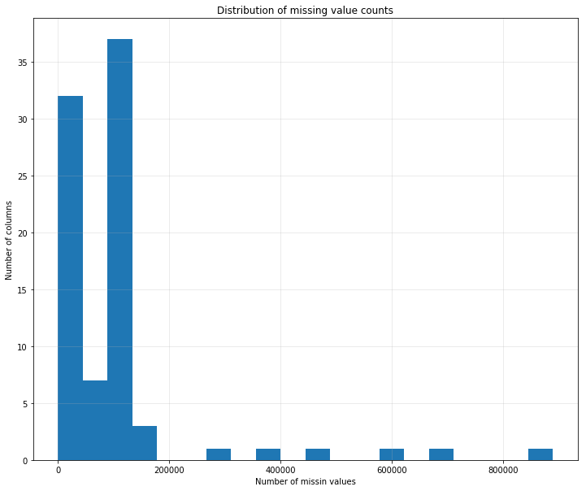

```python
# Investigate patterns in the amount of missing data in each column.
hlp.plot_nan_dist(azdias_edt)
```

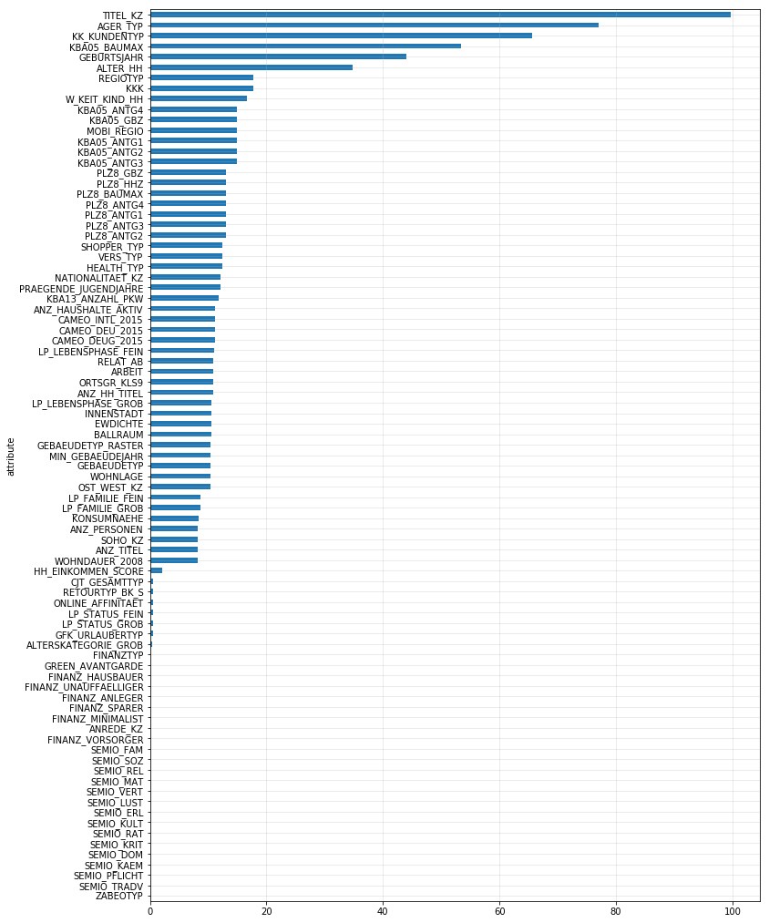

```python
hlp.plot_col_nan(azdias_edt)
```

```python
hlp.get_top_missing(azdias_edt, top_n=34)
```

```
['ALTER_HH',
 'GEBURTSJAHR',
 'KBA05_BAUMAX',
 'KK_KUNDENTYP',
 'AGER_TYP',
 'TITEL_KZ']
```

```python
# Remove the outlier columns from the dataset. (You'll perform other data
# engineering tasks such as re-encoding and imputation later.)
drop_cols = hlp.get_top_missing(azdias_edt, top_n=34)
azdias_flt = azdias_edt.drop(drop_cols, axis=1)
```

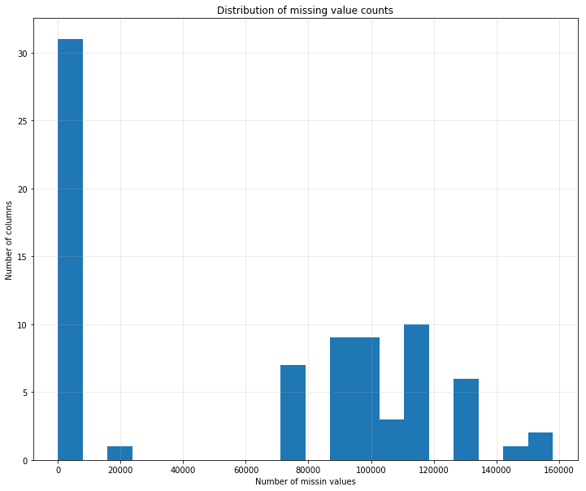

```python
hlp.plot_nan_dist(azdias_flt)
```

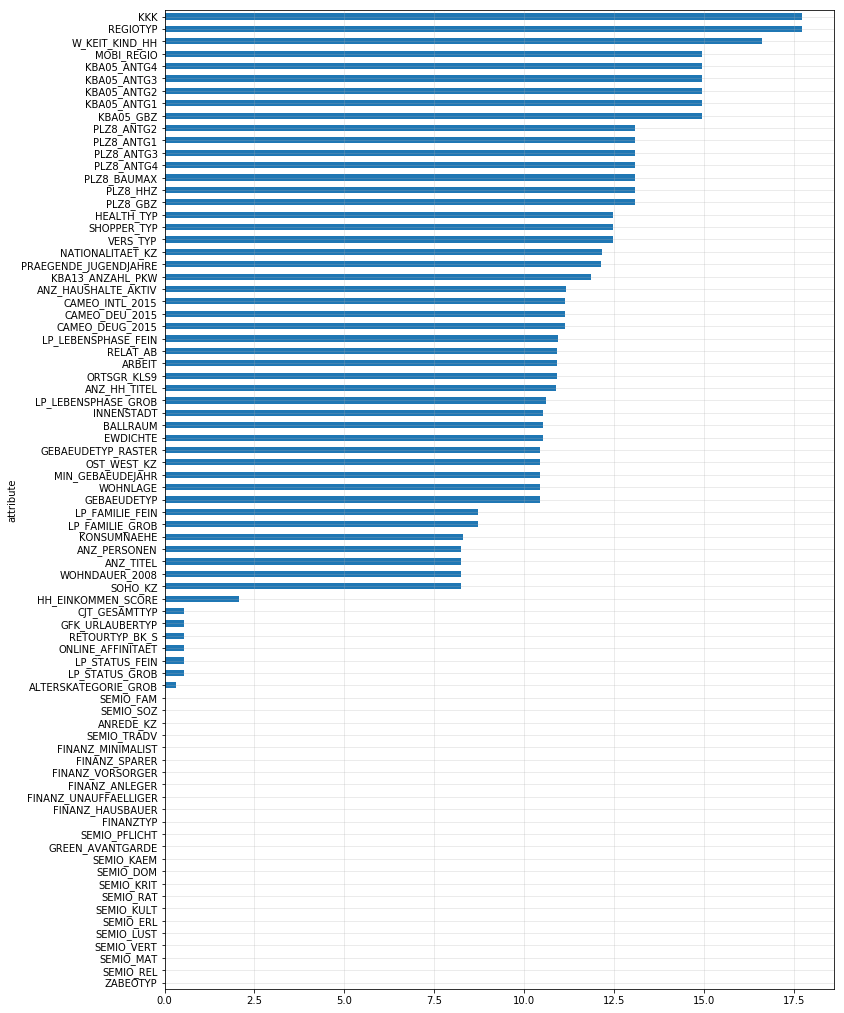

```python
hlp.plot_col_nan(azdias_flt)
```

```python
print(hlp.get_total_missing_count(azdias_flt))
```

```
5035304
```

#### Discussion 1.1.2: Assess Missing Data in Each Column

The number of missing values in the demographics dataframe was found to be `4,896,838`. The dataframe with the features data shows that there are still many missing values that are not encoded as `NaN`. This indicates that the number of missing values in the dataframe is much bigger that the mentioned number above.

- Using the features data dataframe, all missing values has been replaced with `NaN`.
- The total number of missing values in the dataframe after replacement is `8,373,929`. Almost double the number of missing values before replacement.
- The variable `TITEL_KZ` cotains almost onlt missing values, 99.75% missing values.
- Other than `TITEL_KZ`, these columns are the ones with the most missing values: `ALTER_HH`, `GEBURTSJAHR`, `KBA05_BAUMAX`, `KK_KUNDENTYP`, `AGER_TYP`. Most of these variable has more than 50% missing values.
- All the above mentioned variables were dropped from the dataframe.
- After removing those variable, the highest missing value percentage is now about 17.5%
- The total number of missing values in the dataframe is now `5,035,304`.

#### Step 1.1.3: Assess Missing Data in Each Row

Now, you'll perform a similar assessment for the rows of the dataset. How much data is missing in each row? As with the columns, you should see some groups of points that have a very different numbers of missing values. Divide the data into two subsets: one for data points that are above some threshold for missing values, and a second subset for points below that threshold.

In order to know what to do with the outlier rows, we should see if the distribution of data values on columns that are not missing data (or are missing very little data) are similar or different between the two groups. Select at least five of these columns and compare the distribution of values.

- You can use seaborn's [`countplot()`](https://seaborn.pydata.org/generated/seaborn.countplot.html) function to create a bar chart of code frequencies and matplotlib's [`subplot()`](https://matplotlib.org/api/_as_gen/matplotlib.pyplot.subplot.html) function to put bar charts for the two subplots side by side.
- To reduce repeated code, you might want to write a function that can perform this comparison, taking as one of its arguments a column to be compared.

Depending on what you observe in your comparison, this will have implications on how you approach your conclusions later in the analysis. If the distributions of non-missing features look similar between the data with many missing values and the data with few or no missing values, then we could argue that simply dropping those points from the analysis won't present a major issue. On the other hand, if the data with many missing values looks very different from the data with few or no missing values, then we should make a note on those data as special. We'll revisit these data later on. **Either way, you should continue your analysis for now using just the subset of the data with few or no missing values.**

```python
# How much data is missing in each row of the dataset?
azdias_nan_row = hlp.add_missing_summarie(azdias_flt)
azdias_nan_row.sort_values("missing_percentages", ascending=False).head().T
```

|  | 732775 | 643174 | 472919 | 345274 | 299868 |
| --- | --- | --- | --- | --- | --- |
| ALTERSKATEGORIE_GROB | 3 | 3 | 1 | 1 | 2 |
| ANREDE_KZ | 2 | 1 | 1 | 2 | 2 |
| CJT_GESAMTTYP | NaN | NaN | NaN | 6 | 6 |
| FINANZ_MINIMALIST | 3 | 2 | 5 | 3 | 3 |
| FINANZ_SPARER | 5 | 5 | 1 | 4 | 4 |
| FINANZ_VORSORGER | 3 | 3 | 5 | 3 | 3 |
| FINANZ_ANLEGER | 5 | 5 | 2 | 5 | 5 |
| FINANZ_UNAUFFAELLIGER | 5 | 5 | 3 | 5 | 5 |
| FINANZ_HAUSBAUER | 2 | 2 | 2 | 3 | 3 |
| FINANZTYP | 4 | 4 | 2 | 4 | 4 |
| GFK_URLAUBERTYP | NaN | NaN | NaN | 5 | 5 |
| GREEN_AVANTGARDE | 0 | 0 | 0 | 0 | 0 |
| HEALTH_TYP | NaN | NaN | NaN | NaN | NaN |
| LP_LEBENSPHASE_FEIN | NaN | NaN | NaN | NaN | NaN |
| LP_LEBENSPHASE_GROB | NaN | NaN | NaN | NaN | NaN |
| LP_FAMILIE_FEIN | NaN | NaN | NaN | NaN | NaN |
| LP_FAMILIE_GROB | NaN | NaN | NaN | NaN | NaN |
| LP_STATUS_FEIN | NaN | NaN | NaN | 5 | 5 |
| LP_STATUS_GROB | NaN | NaN | NaN | 2 | 2 |
| NATIONALITAET_KZ | NaN | NaN | NaN | NaN | NaN |
| PRAEGENDE_JUGENDJAHRE | NaN | NaN | 8 | NaN | NaN |
| RETOURTYP_BK_S | NaN | NaN | NaN | 3 | 3 |
| SEMIO_SOZ | 2 | 4 | 4 | 2 | 2 |
| SEMIO_FAM | 6 | 6 | 6 | 6 | 6 |
| SEMIO_REL | 7 | 7 | 7 | 7 | 7 |
| SEMIO_MAT | 5 | 5 | 5 | 5 | 5 |
| SEMIO_VERT | 1 | 7 | 7 | 1 | 1 |
| SEMIO_LUST | 5 | 5 | 5 | 5 | 5 |
| SEMIO_ERL | 3 | 3 | 3 | 3 | 3 |
| SEMIO_KULT | 3 | 4 | 4 | 3 | 3 |
| ... | ... | ... | ... | ... | ... |
| WOHNLAGE | NaN | NaN | NaN | NaN | NaN |
| CAMEO_DEUG_2015 | NaN | NaN | NaN | NaN | NaN |
| CAMEO_DEU_2015 | NaN | NaN | NaN | NaN | NaN |
| CAMEO_INTL_2015 | NaN | NaN | NaN | NaN | NaN |
| KBA05_ANTG1 | NaN | NaN | NaN | NaN | NaN |
| KBA05_ANTG2 | NaN | NaN | NaN | NaN | NaN |
| KBA05_ANTG3 | NaN | NaN | NaN | NaN | NaN |
| KBA05_ANTG4 | NaN | NaN | NaN | NaN | NaN |
| KBA05_GBZ | NaN | NaN | NaN | NaN | NaN |
| BALLRAUM | NaN | NaN | NaN | NaN | NaN |
| EWDICHTE | NaN | NaN | NaN | NaN | NaN |
| INNENSTADT | NaN | NaN | NaN | NaN | NaN |
| GEBAEUDETYP_RASTER | NaN | NaN | NaN | NaN | NaN |
| KKK | NaN | NaN | NaN | NaN | NaN |
| MOBI_REGIO | NaN | NaN | NaN | NaN | NaN |
| ONLINE_AFFINITAET | NaN | NaN | NaN | 2 | 2 |
| REGIOTYP | NaN | NaN | NaN | NaN | NaN |
| KBA13_ANZAHL_PKW | NaN | NaN | NaN | NaN | NaN |
| PLZ8_ANTG1 | NaN | NaN | NaN | NaN | NaN |
| PLZ8_ANTG2 | NaN | NaN | NaN | NaN | NaN |
| PLZ8_ANTG3 | NaN | NaN | NaN | NaN | NaN |
| PLZ8_ANTG4 | NaN | NaN | NaN | NaN | NaN |
| PLZ8_BAUMAX | NaN | NaN | NaN | NaN | NaN |
| PLZ8_HHZ | NaN | NaN | NaN | NaN | NaN |
| PLZ8_GBZ | NaN | NaN | NaN | NaN | NaN |
| ARBEIT | NaN | NaN | NaN | NaN | NaN |
| ORTSGR_KLS9 | NaN | NaN | NaN | NaN | NaN |
| RELAT_AB | NaN | NaN | NaN | NaN | NaN |
| missing_counts | 49 | 49 | 48 | 47 | 47 |
| missing_percentages | 61.25 | 61.25 | 60 | 58.75 | 58.75 |

81 rows × 5 columns

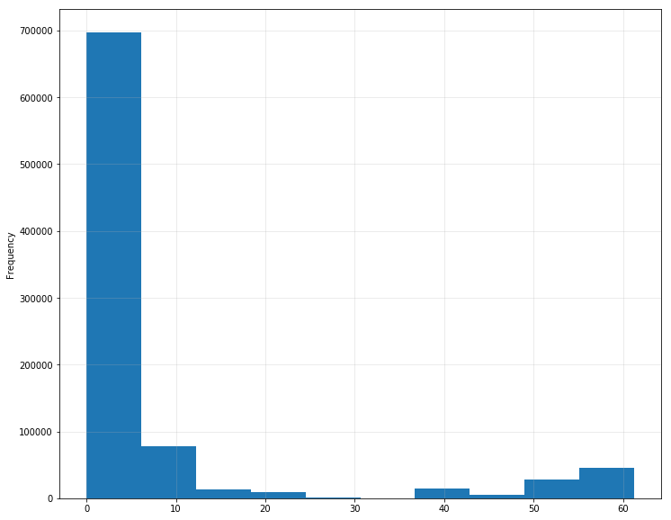

```python
# The distibution of row nan percentage
azdias_nan_row["missing_percentages"].plot(kind="hist", color="C0", figsize=(12, 10));
```

```python
# Write code to divide the data into two subsets based on the number of missing
# values in each row.

below_15 = azdias_nan_row["missing_percentages"] < 15
above_15 = azdias_nan_row["missing_percentages"] > 15

azdias_below_15, azdias_above_15 = azdias_nan_row.loc[below_15], azdias_nan_row.loc[above_15]
```

```python
print(f"- The number of rows in the subset with less than 15% missing values in each row: {azdias_below_15.shape[0]}")
print(f"- The number of rows in the subset with more than 15% missing values in each row: {azdias_above_15.shape[0]}")
```

```
- The number of rows in the subset with less than 15% missing values in each row: 781280
- The number of rows in the subset with more than 15% missing values in each row: 109175
```

```python
# Get columns with no missing values
cols_no_nan = hlp.get_cols_naperc(azdias_nan_row)
cols_no_nan
```

```
['missing_percentages',
 'SEMIO_FAM',
 'SEMIO_SOZ',
 'SEMIO_VERT',
 'SEMIO_LUST',
 'SEMIO_ERL',
 'SEMIO_KULT',
 'SEMIO_RAT',
 'SEMIO_KRIT',
 'SEMIO_DOM',
 'SEMIO_KAEM',
 'SEMIO_PFLICHT',
 'SEMIO_TRADV',
 'GREEN_AVANTGARDE',
 'ZABEOTYP',
 'FINANZTYP',
 'FINANZ_HAUSBAUER',
 'FINANZ_UNAUFFAELLIGER',
 'FINANZ_ANLEGER',
 'FINANZ_VORSORGER',
 'FINANZ_SPARER',
 'FINANZ_MINIMALIST',
 'missing_counts',
 'ANREDE_KZ',
 'SEMIO_REL',
 'SEMIO_MAT']
```

```python
# Choose 5 random columns to use in comparing the two dataframes
cols_to_compare = ["WOHNLAGE", "ZABEOTYP", "GREEN_AVANTGARDE", "SOHO_KZ", "GEBAEUDETYP"]
```

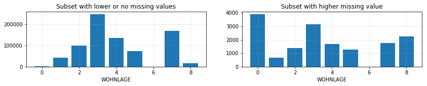

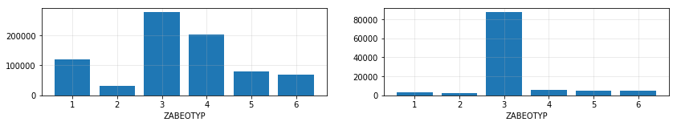

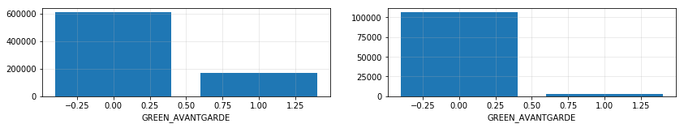

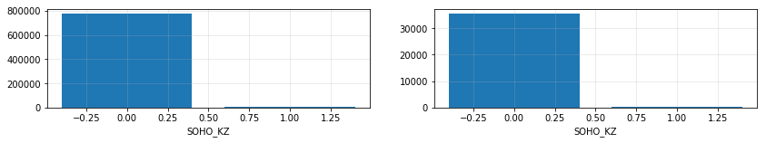

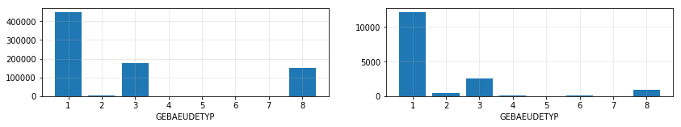

```python
# Compare the distribution of values for at least five columns where there are
# no or few missing values, between the two subsets.

hlp.compare_cols(azdias_below_15, azdias_above_15, cols_to_compare)
```

```python
print(hlp.get_total_missing_count(azdias_nan_row))
print(hlp.get_total_missing_count(azdias_below_15))
```

```
5035304
756715
```

#### Discussion 1.1.3: Assess Missing Data in Each Row

After assessing and dealing with the missing values in the columns, we ended with a dataframe containing `5,035,304` missing values. Now we are going to assess missing values in each row in the dataframe.

### Step 1.2: Select and Re-Encode Features

Checking for missing data isn't the only way in which you can prepare a dataset for analysis. Since the unsupervised learning techniques to be used will only work on data that is encoded numerically, you need to make a few encoding changes or additional assumptions to be able to make progress. In addition, while almost all of the values in the dataset are encoded using numbers, not all of them represent numeric values. Check the third column of the feature summary (`feat_info`) for a summary of types of measurement.

- For numeric and interval data, these features can be kept without changes.
- Most of the variables in the dataset are ordinal in nature. While ordinal values may technically be non-linear in spacing, make the simplifying assumption that the ordinal variables can be treated as being interval in nature (that is, kept without any changes).
- Special handling may be necessary for the remaining two variable types: categorical, and 'mixed'.

In the first two parts of this sub-step, you will perform an investigation of the categorical and mixed-type features and make a decision on each of them, whether you will keep, drop, or re-encode each. Then, in the last part, you will create a new data frame with only the selected and engineered columns.

Data wrangling is often the trickiest part of the data analysis process, and there's a lot of it to be done here. But stick with it: once you're done with this step, you'll be ready to get to the machine learning parts of the project!

```python
print(feat_info["type"].unique(), "\n")
print(feat_info.groupby("type").count()["attribute"])
```

```
['categorical' 'ordinal' 'numeric' 'mixed' 'interval']

type
categorical    21
interval        1
mixed           7
numeric         7
ordinal        49
Name: attribute, dtype: int64
```

```python
attribute_types = feat_info.groupby("type").count()["attribute"].to_dict()
attribute_types
```

```
{'categorical': 21, 'interval': 1, 'mixed': 7, 'numeric': 7, 'ordinal': 49}
```

```python
# How many features are there of each data type?
hlp.count_col_types(azdias_below_15, summary=None)
```

```
{dtype('float64'): 52, dtype('int64'): 25, dtype('O'): 4}
```

```python
hlp.count_col_types(azdias_below_15, summary=feat_info)
```

```
{'categorical': 21, 'interval': 1, 'mixed': 7, 'numeric': 7, 'ordinal': 49}
```

#### Step 1.2.1: Re-Encode Categorical Features

For categorical data, you would ordinarily need to encode the levels as dummy variables. Depending on the number of categories, perform one of the following:

- For binary (two-level) categoricals that take numeric values, you can keep them without needing to do anything.
- There is one binary variable that takes on non-numeric values. For this one, you need to re-encode the values as numbers or create a dummy variable.
- For multi-level categoricals (three or more values), you can choose to encode the values using multiple dummy variables (e.g. via [OneHotEncoder](http://scikit-learn.org/stable/modules/generated/sklearn.preprocessing.OneHotEncoder.html)), or (to keep things straightforward) just drop them from the analysis. As always, document your choices in the Discussion section.

The binary variable that takes on non-numeric values is `OST_WEST_KZ` which represents Building location via former East / West Germany (GDR / FRG):

- -1: unknown
- O: East (GDR)
- W: West (FRG)

```python
# Assess categorical variables: which are binary, which are multi-level, and
# which one needs to be re-encoded?
print(len(hlp.get_cat_features(azdias_below_15, feat_info)))
hlp.get_cat_features(azdias_below_15, feat_info)
```

```
18
```

```
['ANREDE_KZ',
 'CJT_GESAMTTYP',
 'FINANZTYP',
 'GFK_URLAUBERTYP',
 'GREEN_AVANTGARDE',
 'LP_FAMILIE_FEIN',
 'LP_FAMILIE_GROB',
 'LP_STATUS_FEIN',
 'LP_STATUS_GROB',
 'NATIONALITAET_KZ',
 'SHOPPER_TYP',
 'SOHO_KZ',
 'VERS_TYP',
 'ZABEOTYP',
 'GEBAEUDETYP',
 'OST_WEST_KZ',
 'CAMEO_DEUG_2015',
 'CAMEO_DEU_2015']
```

```python
azdias_below_15[hlp.get_cat_features(azdias_below_15, feat_info)].info()
```

```
<class 'pandas.core.frame.DataFrame'>
Int64Index: 781280 entries, 1 to 891220
Data columns (total 18 columns):
ANREDE_KZ           781280 non-null int64
CJT_GESAMTTYP       777401 non-null float64
FINANZTYP           781280 non-null int64
GFK_URLAUBERTYP     777401 non-null float64
GREEN_AVANTGARDE    781280 non-null int64
LP_FAMILIE_FEIN     752071 non-null float64
LP_FAMILIE_GROB     752071 non-null float64
LP_STATUS_FEIN      777401 non-null float64
LP_STATUS_GROB      777401 non-null float64
NATIONALITAET_KZ    749164 non-null float64
SHOPPER_TYP         746520 non-null float64
SOHO_KZ             781280 non-null float64
VERS_TYP            746520 non-null float64
ZABEOTYP            781280 non-null int64
GEBAEUDETYP         781280 non-null float64
OST_WEST_KZ         781280 non-null object
CAMEO_DEUG_2015     777173 non-null object
CAMEO_DEU_2015      777173 non-null object
dtypes: float64(11), int64(4), object(3)
memory usage: 113.3+ MB
```

```python
# Finding the non-numeric binary categorical variable
cat_cols = hlp.get_cat_features(azdias_below_15, feat_info)
binary_cols = hlp.get_binary_feats(azdias_below_15, cat_cols)
for col in binary_cols:
    print(col, azdias_below_15[col].unique())
```

```
ANREDE_KZ [2 1]
GREEN_AVANTGARDE [0 1]
SOHO_KZ [ 1.  0.]
OST_WEST_KZ ['W' 'O']
```

```python
# Re-encode categorical variable(s) to be kept in the analysis.
azdias_below_15["OST_WEST_KZ"] = azdias_below_15["OST_WEST_KZ"].map({'W': 1, 'O': 0})
```

```python
binary_cols = hlp.get_binary_feats(azdias_below_15, cat_cols)
for col in binary_cols:
    print(col, azdias_below_15[col].unique())
```

```
ANREDE_KZ [2 1]
GREEN_AVANTGARDE [0 1]
SOHO_KZ [ 1.  0.]
OST_WEST_KZ [1 0]
```

#### The remaining categorical features:

- `CAMEO_DEUG_2015`: This attribute describes Wealth / Life Stage Typology on a rough scale.
- `CAMEO_DEU_2015`: This attribute contains the same information in the previous 2 attributes but on a detailed scale. We can do without it.

```python
azdias_below_15["CAMEO_DEUG_2015"] = azdias_below_15["CAMEO_DEUG_2015"].astype('Float64')
azdias_below_15 = azdias_below_15.drop(["CAMEO_DEU_2015"], axis=1)
```

#### Step 1.2.2: Engineer Mixed-Type Features

There are a handful of features that are marked as "mixed" in the feature summary that require special treatment in order to be included in the analysis. There are two in particular that deserve attention; the handling of the rest are up to your own choices:

- "PRAEGENDE_JUGENDJAHRE" combines information on three dimensions: generation by decade, movement (mainstream vs. avantgarde), and nation (east vs. west). While there aren't enough levels to disentangle east from west, you should create two new variables to capture the other two dimensions: an interval-type variable for decade, and a binary variable for movement.
- "CAMEO_INTL_2015" combines information on two axes: wealth and life stage. Break up the two-digit codes by their 'tens'-place and 'ones'-place digits into two new ordinal variables (which, for the purposes of this project, is equivalent to just treating them as their raw numeric values).
- If you decide to keep or engineer new features around the other mixed-type features, make sure you note your steps in the Discussion section.

Be sure to check `Data_Dictionary.md` for the details needed to finish these tasks.

```python
mixed_cols = hlp.get_mixed_feats(azdias_below_15, feat_info)
for col in mixed_cols:
    print(col, azdias_below_15[col].dtype)
```

```
LP_LEBENSPHASE_FEIN float64
LP_LEBENSPHASE_GROB float64
PRAEGENDE_JUGENDJAHRE float64
WOHNLAGE float64
CAMEO_INTL_2015 object
PLZ8_BAUMAX float64
```

```python
for col in mixed_cols:
    print(col, azdias_below_15[col].unique(), "\n")
```

```
LP_LEBENSPHASE_FEIN [ 21.   3.  nan  32.   8.   2.   5.  10.   4.   6.  23.  12.  20.   1.  25.
  13.  18.  31.  38.  35.  30.   7.  22.  14.  29.  24.  28.  37.  26.  39.
  27.  36.   9.  34.  33.  15.  11.  40.  16.  19.  17.]

LP_LEBENSPHASE_GROB [  6.   1.  nan  10.   2.   3.   5.   7.  12.  11.   9.   4.   8.]

PRAEGENDE_JUGENDJAHRE [ 14.  15.   8.   3.  10.  11.   5.   9.   6.   4.  nan   2.   1.  12.  13.
   7.]

WOHNLAGE [ 4.  2.  7.  3.  5.  1.  8.  0.]

CAMEO_INTL_2015 ['51' '24' '12' '43' '54' '22' '14' '13' '15' '33' '41' '34' '55' '25' nan
 '23' '31' '52' '35' '45' '44' '32']

PLZ8_BAUMAX [  1.   2.  nan   4.   5.   3.]
```

#### `PRAEGENDE_JUGENDJAHRE`

Dominating movement of person's youth (avantgarde vs. mainstream; east vs. west)

- -1: unknown
- 0: unknown
- 1: 40s - war years (Mainstream, E+W)
- 2: 40s - reconstruction years (Avantgarde, E+W)
- 3: 50s - economic miracle (Mainstream, E+W)
- 4: 50s - milk bar / Individualisation (Avantgarde, E+W)
- 5: 60s - economic miracle (Mainstream, E+W)
- 6: 60s - generation 68 / student protestors (Avantgarde, W)
- 7: 60s - opponents to the building of the Wall (Avantgarde, E)
- 8: 70s - family orientation (Mainstream, E+W)
- 9: 70s - peace movement (Avantgarde, E+W)
- 10: 80s - Generation Golf (Mainstream, W)
- 11: 80s - ecological awareness (Avantgarde, W)
- 12: 80s - FDJ / communist party youth organisation (Mainstream, E)
- 13: 80s - Swords into ploughshares (Avantgarde, E)
- 14: 90s - digital media kids (Mainstream, E+W)
- 15: 90s - ecological awareness (Avantgarde, E+W)

#### `CAMEO_INTL_2015`

German CAMEO: Wealth / Life Stage Typology, mapped to international code

- -1: unknown
- 11: Wealthy Households - Pre-Family Couples & Singles
- 12: Wealthy Households - Young Couples With Children
- 13: Wealthy Households - Families With School Age Children
- 14: Wealthy Households - Older Families & Mature Couples
- 15: Wealthy Households - Elders In Retirement
- 21: Prosperous Households - Pre-Family Couples & Singles
- 22: Prosperous Households - Young Couples With Children
- 23: Prosperous Households - Families With School Age Children
- 24: Prosperous Households - Older Families & Mature Couples
- 25: Prosperous Households - Elders In Retirement
- 31: Comfortable Households - Pre-Family Couples & Singles
- 32: Comfortable Households - Young Couples With Children
- 33: Comfortable Households - Families With School Age Children
- 34: Comfortable Households - Older Families & Mature Couples
- 35: Comfortable Households - Elders In Retirement
- 41: Less Affluent Households - Pre-Family Couples & Singles
- 42: Less Affluent Households - Young Couples With Children
- 43: Less Affluent Households - Families With School Age Children
- 44: Less Affluent Households - Older Families & Mature Couples
- 45: Less Affluent Households - Elders In Retirement
- 51: Poorer Households - Pre-Family Couples & Singles
- 52: Poorer Households - Young Couples With Children
- 53: Poorer Households - Families With School Age Children
- 54: Poorer Households - Older Families & Mature Couples
- 55: Poorer Households - Elders In Retirement
- XX: unknown

```python
# Create a look-up table for PRAEGENDE_JUGENDJAHRE
PJ_lookup = {
    1:[41, "Mainstream", "Both"],
    2:[42, "Avantgarde", "Both"],
    3:[51, "Mainstream", "Both"],
    4:[52, "Avantgarde", "Both"],
    5:[61, "Mainstream", "Both"],
    6:[62, "Avantgarde", "W"],
    7:[63, "Avantgarde", "E"],
    8:[71, "Mainstream", "Both"],
    9:[72, "Avantgarde", "Both"],
    10:[81, "Mainstream", "W"],
    11:[82, "Avantgarde", "W"],
    12:[83, "Mainstream", "E"],
    13:[84, "Avantgarde", "E"],
    14:[91, "Mainstream", "Both"],
    15:[92, "Avantgarde", "Both"],
}
```

```python
# Investigate "PRAEGENDE_JUGENDJAHRE" and engineer two new variables.
azdias_below_15["PJ_decade"] = [PJ_lookup[val][0] if not np.isnan(val) else np.nan for val in azdias_below_15["PRAEGENDE_JUGENDJAHRE"]]
azdias_below_15["PJ_movement"] = [1 if (not np.isnan(val) and PJ_lookup[val][1] == "Mainstream") else 0 if (not np.isnan(val) and PJ_lookup[val][1] == "Avantgarde") else np.nan for val in azdias_below_15["PRAEGENDE_JUGENDJAHRE"]]
azdias_below_15["PJ_eastwest"] = [PJ_lookup[val][2] if not np.isnan(val) else np.nan for val in azdias_below_15["PRAEGENDE_JUGENDJAHRE"]]
```

```python
azdias_below_15["PJ_eastwest"] = azdias_below_15["PJ_eastwest"].map({"E":0, "W":1, "Both":2})
```

```python
azdias_below_15[["PRAEGENDE_JUGENDJAHRE", "PJ_decade", "PJ_movement", "PJ_eastwest"]].head(10)
```

|  | PRAEGENDE_JUGENDJAHRE | PJ_decade | PJ_movement | PJ_eastwest |
| --- | --- | --- | --- | --- |
| 1 | 14.0 | 91.0 | 1.0 | 2.0 |
| 2 | 15.0 | 92.0 | 0.0 | 2.0 |
| 3 | 8.0 | 71.0 | 1.0 | 2.0 |
| 4 | 8.0 | 71.0 | 1.0 | 2.0 |
| 5 | 3.0 | 51.0 | 1.0 | 2.0 |
| 6 | 10.0 | 81.0 | 1.0 | 1.0 |
| 7 | 8.0 | 71.0 | 1.0 | 2.0 |
| 8 | 11.0 | 82.0 | 0.0 | 1.0 |
| 9 | 15.0 | 92.0 | 0.0 | 2.0 |
| 10 | 3.0 | 51.0 | 1.0 | 2.0 |

```python
# Investigate "CAMEO_INTL_2015" and engineer two new variables.
azdias_below_15["CI_wealth"] = [int(val[0]) if val not in [np.nan] else np.nan for val in azdias_below_15["CAMEO_INTL_2015"]]
azdias_below_15["CI_life_stage"] = [int(val[1]) if val not in [np.nan] else np.nan for val in azdias_below_15["CAMEO_INTL_2015"]]
```

```python
# Checking engineered columns and their parent columns
azdias_below_15[["PRAEGENDE_JUGENDJAHRE", "PJ_decade", "PJ_movement", "PJ_eastwest", "CAMEO_INTL_2015", "CI_wealth", "CI_life_stage"]].head(10)
```

|  | PRAEGENDE_JUGENDJAHRE | PJ_decade | PJ_movement | PJ_eastwest | CAMEO_INTL_2015 | CI_wealth | CI_life_stage |
| --- | --- | --- | --- | --- | --- | --- | --- |
| 1 | 14.0 | 91.0 | 1.0 | 2.0 | 51 | 5.0 | 1.0 |
| 2 | 15.0 | 92.0 | 0.0 | 2.0 | 24 | 2.0 | 4.0 |
| 3 | 8.0 | 71.0 | 1.0 | 2.0 | 12 | 1.0 | 2.0 |
| 4 | 8.0 | 71.0 | 1.0 | 2.0 | 43 | 4.0 | 3.0 |
| 5 | 3.0 | 51.0 | 1.0 | 2.0 | 54 | 5.0 | 4.0 |
| 6 | 10.0 | 81.0 | 1.0 | 1.0 | 22 | 2.0 | 2.0 |
| 7 | 8.0 | 71.0 | 1.0 | 2.0 | 14 | 1.0 | 4.0 |
| 8 | 11.0 | 82.0 | 0.0 | 1.0 | 13 | 1.0 | 3.0 |
| 9 | 15.0 | 92.0 | 0.0 | 2.0 | 15 | 1.0 | 5.0 |
| 10 | 3.0 | 51.0 | 1.0 | 2.0 | 51 | 5.0 | 1.0 |

```python
# Which categorical features we still need to deal with?
azdias_below_15.info()
```

```
<class 'pandas.core.frame.DataFrame'>
Int64Index: 781280 entries, 1 to 891220
Data columns (total 85 columns):
ALTERSKATEGORIE_GROB     778636 non-null float64
ANREDE_KZ                781280 non-null int64
CJT_GESAMTTYP            777401 non-null float64
FINANZ_MINIMALIST        781280 non-null int64
FINANZ_SPARER            781280 non-null int64
FINANZ_VORSORGER         781280 non-null int64
FINANZ_ANLEGER           781280 non-null int64
FINANZ_UNAUFFAELLIGER    781280 non-null int64
FINANZ_HAUSBAUER         781280 non-null int64
FINANZTYP                781280 non-null int64
GFK_URLAUBERTYP          777401 non-null float64
GREEN_AVANTGARDE         781280 non-null int64
HEALTH_TYP               746520 non-null float64
LP_LEBENSPHASE_FEIN      734256 non-null float64
LP_LEBENSPHASE_GROB      736940 non-null float64
LP_FAMILIE_FEIN          752071 non-null float64
LP_FAMILIE_GROB          752071 non-null float64
LP_STATUS_FEIN           777401 non-null float64
LP_STATUS_GROB           777401 non-null float64
NATIONALITAET_KZ         749164 non-null float64
PRAEGENDE_JUGENDJAHRE    754677 non-null float64
RETOURTYP_BK_S           777401 non-null float64
SEMIO_SOZ                781280 non-null int64
SEMIO_FAM                781280 non-null int64
SEMIO_REL                781280 non-null int64
SEMIO_MAT                781280 non-null int64
SEMIO_VERT               781280 non-null int64
SEMIO_LUST               781280 non-null int64
SEMIO_ERL                781280 non-null int64
SEMIO_KULT               781280 non-null int64
SEMIO_RAT                781280 non-null int64
SEMIO_KRIT               781280 non-null int64
SEMIO_DOM                781280 non-null int64
SEMIO_KAEM               781280 non-null int64
SEMIO_PFLICHT            781280 non-null int64
SEMIO_TRADV              781280 non-null int64
SHOPPER_TYP              746520 non-null float64
```

[output cut: 35 more lines]

```
PLZ8_BAUMAX              772720 non-null float64
PLZ8_HHZ                 772720 non-null float64
PLZ8_GBZ                 772720 non-null float64
ARBEIT                   777167 non-null float64
ORTSGR_KLS9              777259 non-null float64
RELAT_AB                 777167 non-null float64
missing_counts           781280 non-null int64
missing_percentages      781280 non-null float64
PJ_decade                754677 non-null float64
PJ_movement              754677 non-null float64
PJ_eastwest              754677 non-null float64
CI_wealth                777173 non-null float64
CI_life_stage            777173 non-null float64
dtypes: float64(58), int64(26), object(1)
memory usage: 512.6+ MB
```

#### The remaining categorical features:

- `CAMEO_INTL_2015`: This attributed has already been split into two other columns, and will be removed.Note that this attribute contains the same iformation contained in the following 2 attributes but mapped to international standards.

#### Other features to remove:

- `missing_counts`: This attribute is no longer needed and will be removed.
- `missing_percentages`: This attribute is no longer needed and will be removed.

```python
cols_to_drop = ["PRAEGENDE_JUGENDJAHRE", "CAMEO_INTL_2015", "missing_counts", "missing_percentages"]
azdias_final = azdias_below_15.drop(cols_to_drop, axis=1)
```

#### Discussion 1.2.2: Engineer Mixed-Type Features

The dataframe contain some variables that are of mixed types. These variables are found using the features data data frame. These mixed type indicate that each value has more than one dimension or that it indicate many things. The variables of mixed type that we need to deal with are:

1. `PRAEGENDE_JUGENDJAHRE` combines information on three dimensions: generation by decade, movement (mainstream vs. avantgarde), and nation (east vs. west).
2. `CAMEO_INTL_2015` combines information on two axes: wealth and life stage.

These variables of mixed type were engineered and diveded into several features as follows:

- `PRAEGENDE_JUGENDJAHRE` was divided into: `PJ_decade` indicating the decade, `PJ_movement` movement (mainstream vs. avantgarde), `PJ_eastwest` indicating nation (east, west, or both)
- A look-up table was used to extract the value of each column from `PRAEGENDE_JUGENDJAHRE`.
- `PJ_decade` is numeric, so no further processing is needed.
- `PJ_movement` was converted to numeric variable by replacing Mainstream with 1, and Avantgarde with 0.
- `PJ_eastwest` was converted to numeric variable by replacing East with 0, West with 1, and Both with 2.

No look-up table was needed for `CAMEO_INTL_2015`. It has been divided into 2 features: `CI_wealth`, `CI_life_stage`.

- `CI_wealth` was obtained by extracting the tens-place digits from `CAMEO_INTL_2015`.
- `CI_life_stage` was obtained by extracting the ones-place digits from `CAMEO_INTL_2015`.

`PRAEGENDE_JUGENDJAHRE`, and `CAMEO_INTL_2015` were removed after obtaining the necessary information from them. Also `missing_counts` and `missing_percentages` were removed as they are no longer needed. The final dataframe now contain features of only numeric types.

#### Step 1.2.3: Complete Feature Selection

In order to finish this step up, you need to make sure that your data frame now only has the columns that you want to keep. To summarize, the dataframe should consist of the following:

- All numeric, interval, and ordinal type columns from the original dataset.
- Binary categorical features (all numerically-encoded).
- Engineered features from other multi-level categorical features and mixed features.

Make sure that for any new columns that you have engineered, that you've excluded the original columns from the final dataset. Otherwise, their values will interfere with the analysis later on the project. For example, you should not keep "PRAEGENDE_JUGENDJAHRE", since its values won't be useful for the algorithm: only the values derived from it in the engineered features you created should be retained. As a reminder, your data should only be from **the subset with few or no missing values**.

```python
# If there are other re-engineering tasks you need to perform, make sure you
# take care of them here. (Dealing with missing data will come in step 2.1.)
print(azdias_final.shape, "\n")
azdias_final.head()
```

```
(781280, 81)
```

|  | ALTERSKATEGORIE_GROB | ANREDE_KZ | CJT_GESAMTTYP | FINANZ_MINIMALIST | FINANZ_SPARER | FINANZ_VORSORGER | FINANZ_ANLEGER | FINANZ_UNAUFFAELLIGER | FINANZ_HAUSBAUER | FINANZTYP | ... | PLZ8_HHZ | PLZ8_GBZ | ARBEIT | ORTSGR_KLS9 | RELAT_AB | PJ_decade | PJ_movement | PJ_eastwest | CI_wealth | CI_life_stage |
| --- | --- | --- | --- | --- | --- | --- | --- | --- | --- | --- | --- | --- | --- | --- | --- | --- | --- | --- | --- | --- | --- |
| 1 | 1.0 | 2 | 5.0 | 1 | 5 | 2 | 5 | 4 | 5 | 1 | ... | 5.0 | 4.0 | 3.0 | 5.0 | 4.0 | 91.0 | 1.0 | 2.0 | 5.0 | 1.0 |
| 2 | 3.0 | 2 | 3.0 | 1 | 4 | 1 | 2 | 3 | 5 | 1 | ... | 4.0 | 4.0 | 3.0 | 5.0 | 2.0 | 92.0 | 0.0 | 2.0 | 2.0 | 4.0 |
| 3 | 4.0 | 2 | 2.0 | 4 | 2 | 5 | 2 | 1 | 2 | 6 | ... | 3.0 | 4.0 | 2.0 | 3.0 | 3.0 | 71.0 | 1.0 | 2.0 | 1.0 | 2.0 |
| 4 | 3.0 | 1 | 5.0 | 4 | 3 | 4 | 1 | 3 | 2 | 5 | ... | 3.0 | 3.0 | 4.0 | 6.0 | 5.0 | 71.0 | 1.0 | 2.0 | 4.0 | 3.0 |
| 5 | 1.0 | 2 | 2.0 | 3 | 1 | 5 | 2 | 2 | 5 | 2 | ... | 5.0 | 5.0 | 2.0 | 3.0 | 3.0 | 51.0 | 1.0 | 2.0 | 5.0 | 4.0 |

5 rows × 81 columns

```python
# Do whatever you need to in order to ensure that the dataframe only contains
# the columns that should be passed to the algorithm functions.

azdias_final.info()
```

```
<class 'pandas.core.frame.DataFrame'>
Int64Index: 781280 entries, 1 to 891220
Data columns (total 81 columns):
ALTERSKATEGORIE_GROB     778636 non-null float64
ANREDE_KZ                781280 non-null int64
CJT_GESAMTTYP            777401 non-null float64
FINANZ_MINIMALIST        781280 non-null int64
FINANZ_SPARER            781280 non-null int64
FINANZ_VORSORGER         781280 non-null int64
FINANZ_ANLEGER           781280 non-null int64
FINANZ_UNAUFFAELLIGER    781280 non-null int64
FINANZ_HAUSBAUER         781280 non-null int64
FINANZTYP                781280 non-null int64
GFK_URLAUBERTYP          777401 non-null float64
GREEN_AVANTGARDE         781280 non-null int64
HEALTH_TYP               746520 non-null float64
LP_LEBENSPHASE_FEIN      734256 non-null float64
LP_LEBENSPHASE_GROB      736940 non-null float64
LP_FAMILIE_FEIN          752071 non-null float64
LP_FAMILIE_GROB          752071 non-null float64
LP_STATUS_FEIN           777401 non-null float64
LP_STATUS_GROB           777401 non-null float64
NATIONALITAET_KZ         749164 non-null float64
RETOURTYP_BK_S           777401 non-null float64
SEMIO_SOZ                781280 non-null int64
SEMIO_FAM                781280 non-null int64
SEMIO_REL                781280 non-null int64
SEMIO_MAT                781280 non-null int64
SEMIO_VERT               781280 non-null int64
SEMIO_LUST               781280 non-null int64
SEMIO_ERL                781280 non-null int64
SEMIO_KULT               781280 non-null int64
SEMIO_RAT                781280 non-null int64
SEMIO_KRIT               781280 non-null int64
SEMIO_DOM                781280 non-null int64
SEMIO_KAEM               781280 non-null int64
SEMIO_PFLICHT            781280 non-null int64
SEMIO_TRADV              781280 non-null int64
SHOPPER_TYP              746520 non-null float64
SOHO_KZ                  781280 non-null float64
```

[output cut: 31 more lines]

```
PLZ8_ANTG3               772720 non-null float64
PLZ8_ANTG4               772720 non-null float64
PLZ8_BAUMAX              772720 non-null float64
PLZ8_HHZ                 772720 non-null float64
PLZ8_GBZ                 772720 non-null float64
ARBEIT                   777167 non-null float64
ORTSGR_KLS9              777259 non-null float64
RELAT_AB                 777167 non-null float64
PJ_decade                754677 non-null float64
PJ_movement              754677 non-null float64
PJ_eastwest              754677 non-null float64
CI_wealth                777173 non-null float64
CI_life_stage            777173 non-null float64
dtypes: float64(56), int64(25)
memory usage: 488.8 MB
```

```python
def eng_cat_feats(df):
    PJ_lookup = {
        1:[41, "Mainstream", "Both"],
        2:[42, "Avantgarde", "Both"],
        3:[51, "Mainstream", "Both"],
        4:[52, "Avantgarde", "Both"],
        5:[61, "Mainstream", "Both"],
        6:[62, "Avantgarde", "W"],
        7:[63, "Avantgarde", "E"],
        8:[71, "Mainstream", "Both"],
        9:[72, "Avantgarde", "Both"],
        10:[81, "Mainstream", "W"],
        11:[82, "Avantgarde", "W"],
        12:[83, "Mainstream", "E"],
        13:[84, "Avantgarde", "E"],
        14:[91, "Mainstream", "Both"],
        15:[92, "Avantgarde", "Both"],
    }

    df["OST_WEST_KZ"] = df["OST_WEST_KZ"].map({'W': 1, 'O': 0})
    df["PJ_decade"] = [PJ_lookup[val][0] if not np.isnan(val) else np.nan for val in df["PRAEGENDE_JUGENDJAHRE"]]
    df["PJ_movement"] = [1 if (not np.isnan(val) and PJ_lookup[val][1] == "Mainstream") else 0 if (not np.isnan(val) and PJ_lookup[val][1] == "Avantgarde") else np.nan for val in df["PRAEGENDE_JUGENDJAHRE"]]
    df["PJ_eastwest"] = [PJ_lookup[val][2] if not np.isnan(val) else np.nan for val in df["PRAEGENDE_JUGENDJAHRE"]]
    df["PJ_eastwest"] = df["PJ_eastwest"].map({"E":0, "W":1, "Both":2})
    df["CI_wealth"] = [int(val[0]) if val not in [np.nan] else np.nan for val in df["CAMEO_INTL_2015"]]
    df["CI_life_stage"] = [int(val[1]) if val not in [np.nan] else np.nan for val in df["CAMEO_INTL_2015"]]
    df["CAMEO_DEUG_2015"] = df["CAMEO_DEUG_2015"].astype('Float64')

    cols_to_drop = ["PRAEGENDE_JUGENDJAHRE", "CAMEO_INTL_2015", "CAMEO_DEU_2015", "missing_counts", "missing_percentages"]
    df = df.drop(cols_to_drop, axis=1)

    return df
```

### Step 1.3: Create a Cleaning Function

Even though you've finished cleaning up the general population demographics data, it's important to look ahead to the future and realize that you'll need to perform the same cleaning steps on the customer demographics data. In this substep, complete the function below to execute the main feature selection, encoding, and re-engineering steps you performed above. Then, when it comes to looking at the customer data in Step 3, you can just run this function on that DataFrame to get the trimmed dataset in a single step.

```python
def clean_data(df, summary, col_nan_perc):
    """
    Perform feature trimming, re-encoding, and engineering for demographics
    data

    INPUT: Demographics DataFrame
    OUTPUT: Trimmed and cleaned demographics DataFrame
    """

    # Put in code here to execute all main cleaning steps:
    # convert missing value codes into NaNs, ...
    df = hlp.convert_to_nan(df, summary)
    print("Converting missing value codes to NaNs is COMPLETE \n")

    # remove selected columns
    nan_summaries = hlp.get_nan_summaries(df)
    drop_cols = hlp.get_top_missing(df, top_n=col_nan_perc)
    df = df.drop(drop_cols, axis=1)

    # remove selected rows
    df = hlp.add_missing_summarie(df)
    df = df.loc[df["missing_percentages"] < 15]


    # select, re-encode, and engineer column values.
    result = eng_cat_feats(df)
    print("Cleaning is now COMPLETE")

    # Return the cleaned dataframe.
    return result
```

## Step 2: Feature Transformation

### Step 2.1: Apply Feature Scaling

Before we apply dimensionality reduction techniques to the data, we need to perform feature scaling so that the principal component vectors are not influenced by the natural differences in scale for features. Starting from this part of the project, you'll want to keep an eye on the [API reference page for sklearn](http://scikit-learn.org/stable/modules/classes.html) to help you navigate to all of the classes and functions that you'll need. In this substep, you'll need to check the following:

- sklearn requires that data not have missing values in order for its estimators to work properly. So, before applying the scaler to your data, make sure that you've cleaned the DataFrame of the remaining missing values. This can be as simple as just removing all data points with missing data, or applying an [Imputer](https://scikit-learn.org/0.16/modules/generated/sklearn.preprocessing.Imputer.html) to replace all missing values. You might also try a more complicated procedure where you temporarily remove missing values in order to compute the scaling parameters before re-introducing those missing values and applying imputation. Think about how much missing data you have and what possible effects each approach might have on your analysis, and justify your decision in the discussion section below.
- For the actual scaling function, a [StandardScaler](http://scikit-learn.org/stable/modules/generated/sklearn.preprocessing.StandardScaler.html) instance is suggested, scaling each feature to mean 0 and standard deviation 1.
- For these classes, you can make use of the `.fit_transform()` method to both fit a procedure to the data as well as apply the transformation to the data at the same time. Don't forget to keep the fit sklearn objects handy, since you'll be applying them to the customer demographics data towards the end of the project.

```python
# If you've not yet cleaned the dataset of all NaN values, then investigate and
# do that now.
azdias_final.head()
```

|  | ALTERSKATEGORIE_GROB | ANREDE_KZ | CJT_GESAMTTYP | FINANZ_MINIMALIST | FINANZ_SPARER | FINANZ_VORSORGER | FINANZ_ANLEGER | FINANZ_UNAUFFAELLIGER | FINANZ_HAUSBAUER | FINANZTYP | ... | PLZ8_HHZ | PLZ8_GBZ | ARBEIT | ORTSGR_KLS9 | RELAT_AB | PJ_decade | PJ_movement | PJ_eastwest | CI_wealth | CI_life_stage |
| --- | --- | --- | --- | --- | --- | --- | --- | --- | --- | --- | --- | --- | --- | --- | --- | --- | --- | --- | --- | --- | --- |
| 1 | 1.0 | 2 | 5.0 | 1 | 5 | 2 | 5 | 4 | 5 | 1 | ... | 5.0 | 4.0 | 3.0 | 5.0 | 4.0 | 91.0 | 1.0 | 2.0 | 5.0 | 1.0 |
| 2 | 3.0 | 2 | 3.0 | 1 | 4 | 1 | 2 | 3 | 5 | 1 | ... | 4.0 | 4.0 | 3.0 | 5.0 | 2.0 | 92.0 | 0.0 | 2.0 | 2.0 | 4.0 |
| 3 | 4.0 | 2 | 2.0 | 4 | 2 | 5 | 2 | 1 | 2 | 6 | ... | 3.0 | 4.0 | 2.0 | 3.0 | 3.0 | 71.0 | 1.0 | 2.0 | 1.0 | 2.0 |
| 4 | 3.0 | 1 | 5.0 | 4 | 3 | 4 | 1 | 3 | 2 | 5 | ... | 3.0 | 3.0 | 4.0 | 6.0 | 5.0 | 71.0 | 1.0 | 2.0 | 4.0 | 3.0 |
| 5 | 1.0 | 2 | 2.0 | 3 | 1 | 5 | 2 | 2 | 5 | 2 | ... | 5.0 | 5.0 | 2.0 | 3.0 | 3.0 | 51.0 | 1.0 | 2.0 | 5.0 | 4.0 |

5 rows × 81 columns

```python
imputer = Imputer(strategy="most_frequent")
azdias_imputed = imputer.fit_transform(azdias_final)
```

```python
# Apply feature scaling to the general population demographics data.
scaler = StandardScaler()
azdias_scaled = scaler.fit_transform(azdias_imputed)
```

```python
azdias_scaled = pd.DataFrame(azdias_scaled, columns=azdias_final.columns)
azdias_scaled.head()
```

|  | ALTERSKATEGORIE_GROB | ANREDE_KZ | CJT_GESAMTTYP | FINANZ_MINIMALIST | FINANZ_SPARER | FINANZ_VORSORGER | FINANZ_ANLEGER | FINANZ_UNAUFFAELLIGER | FINANZ_HAUSBAUER | FINANZTYP | ... | PLZ8_HHZ | PLZ8_GBZ | ARBEIT | ORTSGR_KLS9 | RELAT_AB | PJ_decade | PJ_movement | PJ_eastwest | CI_wealth | CI_life_stage |
| --- | --- | --- | --- | --- | --- | --- | --- | --- | --- | --- | --- | --- | --- | --- | --- | --- | --- | --- | --- | --- | --- |
| 0 | -1.767627 | 0.958344 | 0.977849 | -1.488353 | 1.539115 | -1.045210 | 1.467074 | 0.979459 | 1.327259 | -1.347672 | ... | 1.436314 | 0.563976 | -0.178847 | -0.132442 | 0.679856 | 1.084062 | 0.531088 | 0.508314 | 1.170379 | -1.248871 |
| 1 | 0.198180 | 0.958344 | -0.326330 | -1.488353 | 0.866549 | -1.771603 | -0.569168 | 0.261984 | 1.327259 | -1.347672 | ... | 0.405884 | 0.563976 | -0.178847 | -0.132442 | -0.795261 | 1.152277 | -1.882928 | 0.508314 | -0.874703 | 0.764451 |
| 2 | 1.181083 | 0.958344 | -0.978420 | 0.688484 | -0.478584 | 1.133969 | -0.569168 | -1.172966 | -0.817043 | 1.044831 | ... | -0.624547 | 0.563976 | -1.182794 | -1.003345 | -0.057702 | -0.280244 | 0.531088 | 0.508314 | -1.556398 | -0.577763 |
| 3 | 0.198180 | -1.043466 | 0.977849 | 0.688484 | 0.193983 | 0.407576 | -1.247915 | 0.261984 | -0.817043 | 0.566331 | ... | -0.624547 | -0.339994 | 0.825101 | 0.303010 | 1.417414 | -0.280244 | 0.531088 | 0.508314 | 0.488685 | 0.093344 |
| 4 | -1.767627 | 0.958344 | -0.978420 | -0.037129 | -1.151150 | 1.133969 | -0.569168 | -0.455491 | 1.327259 | -0.869171 | ... | 1.436314 | 1.467947 | -1.182794 | -1.003345 | -0.057702 | -1.644550 | 0.531088 | 0.508314 | 1.170379 | 0.764451 |

5 rows × 81 columns

```python
azdias_scaled.describe().T
```

|  | count | mean | std | min | 25% | 50% | 75% | max |
| --- | --- | --- | --- | --- | --- | --- | --- | --- |
| ALTERSKATEGORIE_GROB | 781280.0 | -1.620475e-16 | 1.000001 | -1.767627 | -0.784724 | 0.198180 | 1.181083 | 1.181083 |
| ANREDE_KZ | 781280.0 | 2.319668e-16 | 1.000001 | -1.043466 | -1.043466 | 0.958344 | 0.958344 | 0.958344 |
| CJT_GESAMTTYP | 781280.0 | -1.434400e-16 | 1.000001 | -1.630509 | -0.978420 | 0.325759 | 0.977849 | 1.629938 |
| FINANZ_MINIMALIST | 781280.0 | -8.629864e-17 | 1.000001 | -1.488353 | -0.762741 | -0.037129 | 0.688484 | 1.414096 |
| FINANZ_SPARER | 781280.0 | 9.884918e-17 | 1.000001 | -1.151150 | -1.151150 | 0.193983 | 0.866549 | 1.539115 |
| FINANZ_VORSORGER | 781280.0 | 3.037596e-18 | 1.000001 | -1.771603 | -1.045210 | 0.407576 | 1.133969 | 1.133969 |
| FINANZ_ANLEGER | 781280.0 | -5.554980e-17 | 1.000001 | -1.247915 | -1.247915 | 0.109580 | 0.788327 | 1.467074 |
| FINANZ_UNAUFFAELLIGER | 781280.0 | -7.097424e-17 | 1.000001 | -1.172966 | -1.172966 | -0.455491 | 0.979459 | 1.696933 |
| FINANZ_HAUSBAUER | 781280.0 | 7.173819e-17 | 1.000001 | -1.531810 | -0.817043 | -0.102276 | 0.612491 | 1.327259 |
| FINANZTYP | 781280.0 | 1.427943e-16 | 1.000001 | -1.347672 | -0.869171 | 0.566331 | 1.044831 | 1.044831 |
| GFK_URLAUBERTYP | 781280.0 | 6.247079e-17 | 1.000001 | -1.819335 | -0.978558 | 0.142479 | 0.983256 | 1.263515 |
| GREEN_AVANTGARDE | 781280.0 | -7.903205e-17 | 1.000001 | -0.531088 | -0.531088 | -0.531088 | -0.531088 | 1.882928 |
| HEALTH_TYP | 781280.0 | 1.152968e-16 | 1.000001 | -1.638593 | -0.316208 | -0.316208 | 1.006178 | 1.006178 |
| LP_LEBENSPHASE_FEIN | 781280.0 | 2.347316e-17 | 1.000001 | -1.156293 | -0.834322 | -0.270873 | 0.936519 | 1.982924 |
| LP_LEBENSPHASE_GROB | 781280.0 | 4.838326e-18 | 1.000001 | -1.018344 | -0.748609 | -0.478874 | 0.869803 | 1.948744 |
| LP_FAMILIE_FEIN | 781280.0 | -9.316506e-17 | 1.000001 | -0.718167 | -0.718167 | -0.718167 | 1.072561 | 1.840015 |
| LP_FAMILIE_GROB | 781280.0 | -4.419065e-17 | 1.000001 | -0.784659 | -0.784659 | -0.784659 | 0.990328 | 1.581991 |
| LP_STATUS_FEIN | 781280.0 | 3.763345e-17 | 1.000001 | -1.061204 | -1.061204 | -0.208477 | 1.212735 | 1.496978 |
| LP_STATUS_GROB | 781280.0 | -3.361818e-17 | 1.000001 | -0.951870 | -0.951870 | -0.289635 | 1.034834 | 1.697069 |
| NATIONALITAET_KZ | 781280.0 | -1.641393e-16 | 1.000001 | -0.347000 | -0.347000 | -0.347000 | -0.347000 | 3.946565 |
| RETOURTYP_BK_S | 781280.0 | -8.728995e-17 | 1.000001 | -1.681919 | -0.995627 | 0.376955 | 1.063246 | 1.063246 |
| SEMIO_SOZ | 781280.0 | -5.037498e-17 | 1.000001 | -1.624454 | -1.109615 | -0.079936 | 0.949743 | 1.464583 |
| SEMIO_FAM | 781280.0 | 1.399249e-16 | 1.000001 | -1.629631 | -1.105610 | -0.057567 | 0.990475 | 1.514497 |
| SEMIO_REL | 781280.0 | -3.799723e-17 | 1.000001 | -1.565713 | -0.518706 | 0.004798 | 0.528302 | 1.575310 |
| SEMIO_MAT | 781280.0 | -8.985463e-17 | 1.000001 | -1.500300 | -0.977622 | 0.067732 | 0.590409 | 1.635763 |
| SEMIO_VERT | 781280.0 | 1.435673e-16 | 1.000001 | -1.684949 | -1.169001 | 0.378842 | 0.894790 | 1.410737 |
| SEMIO_LUST | 781280.0 | -1.627933e-18 | 1.000001 | -1.596874 | -1.120828 | 0.307307 | 0.783352 | 1.259397 |
| SEMIO_ERL | 781280.0 | 1.578367e-16 | 1.000001 | -1.984062 | -0.889691 | -0.342506 | 0.751864 | 1.299049 |
| SEMIO_KULT | 781280.0 | 1.455363e-16 | 1.000001 | -1.605117 | -0.583052 | -0.072020 | 0.950045 | 1.461077 |
| SEMIO_RAT | 781280.0 | -1.065705e-16 | 1.000001 | -1.745038 | -0.536010 | 0.068504 | 0.673018 | 1.882045 |
| ... | ... | ... | ... | ... | ... | ... | ... | ... |
| CAMEO_DEUG_2015 | 781280.0 | 1.409663e-17 | 1.000001 | -1.834908 | -1.032062 | 0.172207 | 0.975053 | 1.376476 |
| KBA05_ANTG1 | 781280.0 | -2.833877e-17 | 1.000001 | -1.028647 | -1.028647 | -0.317652 | 1.104338 | 1.815333 |
| KBA05_ANTG2 | 781280.0 | -6.745463e-17 | 1.000001 | -0.983891 | -0.983891 | -0.180861 | 0.622170 | 2.228231 |
| KBA05_ANTG3 | 781280.0 | -8.655329e-17 | 1.000001 | -0.602783 | -0.602783 | -0.602783 | 0.393735 | 2.386769 |
| KBA05_ANTG4 | 781280.0 | 9.931301e-18 | 1.000001 | -0.469469 | -0.469469 | -0.469469 | -0.469469 | 2.700778 |
| KBA05_GBZ | 781280.0 | 1.215402e-16 | 1.000001 | -1.645571 | -0.881270 | -0.116970 | 0.647331 | 1.411632 |
| BALLRAUM | 781280.0 | 1.714332e-16 | 1.000001 | -1.440526 | -0.982996 | 0.389596 | 0.847127 | 1.304657 |
| EWDICHTE | 781280.0 | -6.752739e-17 | 1.000001 | -1.716892 | -1.134945 | 0.028949 | 1.192843 | 1.192843 |
| INNENSTADT | 781280.0 | -8.628045e-17 | 1.000001 | -1.744993 | -0.759554 | 0.225885 | 0.718604 | 1.704043 |
| GEBAEUDETYP_RASTER | 781280.0 | 3.765163e-17 | 1.000001 | -2.965839 | -0.796813 | 0.287700 | 0.287700 | 1.372213 |
| KKK | 781280.0 | 1.162653e-16 | 1.000001 | -1.842376 | -0.786244 | 0.269888 | 0.269888 | 1.326019 |
| MOBI_REGIO | 781280.0 | 2.160876e-17 | 1.000001 | -1.313064 | -0.622267 | 0.068531 | 0.759328 | 2.140923 |
| ONLINE_AFFINITAET | 781280.0 | 2.750661e-17 | 1.000001 | -1.753342 | -1.109756 | 0.177415 | 0.821001 | 1.464587 |
| REGIOTYP | 781280.0 | -1.806369e-16 | 1.000001 | -1.977286 | -0.873546 | 0.230193 | 0.782062 | 1.333932 |
| KBA13_ANZAHL_PKW | 781280.0 | 6.968281e-17 | 1.000001 | -1.811431 | -0.698272 | -0.214163 | 0.461270 | 4.855930 |
| PLZ8_ANTG1 | 781280.0 | -2.111675e-16 | 1.000001 | -2.326232 | -0.258410 | -0.258410 | 0.775501 | 1.809412 |
| PLZ8_ANTG2 | 781280.0 | -9.054582e-17 | 1.000001 | -3.063404 | -0.878879 | 0.213383 | 0.213383 | 1.305646 |
| PLZ8_ANTG3 | 781280.0 | 5.507688e-17 | 1.000001 | -1.629633 | -0.611556 | 0.406521 | 0.406521 | 1.424597 |
| PLZ8_ANTG4 | 781280.0 | 2.101762e-17 | 1.000001 | -0.951913 | -0.951913 | 0.423678 | 0.423678 | 1.799269 |
| PLZ8_BAUMAX | 781280.0 | -7.353892e-17 | 1.000001 | -0.642199 | -0.642199 | -0.642199 | 0.731945 | 2.106090 |
| PLZ8_HHZ | 781280.0 | -1.605924e-16 | 1.000001 | -2.685407 | -0.624547 | -0.624547 | 0.405884 | 1.436314 |
| PLZ8_GBZ | 781280.0 | -2.371871e-17 | 1.000001 | -2.147935 | -0.339994 | -0.339994 | 0.563976 | 1.467947 |
| ARBEIT | 781280.0 | -1.365827e-16 | 1.000001 | -2.186742 | -0.178847 | -0.178847 | 0.825101 | 1.829048 |
| ORTSGR_KLS9 | 781280.0 | 4.388143e-17 | 1.000001 | -1.874249 | -0.567894 | -0.132442 | 0.738462 | 1.609365 |
| RELAT_AB | 781280.0 | 1.346319e-16 | 1.000001 | -1.532819 | -0.795261 | -0.057702 | 0.679856 | 1.417414 |
| PJ_decade | 781280.0 | 2.239090e-16 | 1.000001 | -2.326703 | -0.894182 | 0.401909 | 1.084062 | 1.152277 |
| PJ_movement | 781280.0 | 7.903205e-17 | 1.000001 | -1.882928 | 0.531088 | 0.531088 | 0.531088 | 0.531088 |
| PJ_eastwest | 781280.0 | -1.428852e-16 | 1.000001 | -3.248809 | 0.508314 | 0.508314 | 0.508314 | 0.508314 |
| CI_wealth | 781280.0 | -6.075191e-17 | 1.000001 | -1.556398 | -0.874703 | 0.488685 | 1.170379 | 1.170379 |
| CI_life_stage | 781280.0 | -1.767990e-16 | 1.000001 | -1.248871 | -1.248871 | 0.093344 | 0.764451 | 1.435559 |

81 rows × 8 columns

### Discussion 2.1: Apply Feature Scaling

The final processed demographics dataframe still contains many missing values. The remaining missing values were imputed by the most frequent value in each column before performing any scaling, as scikit-learn requires that data not having missing values in order for its estimators to work properly.

For the scaling, scikit-learn's `StandardScaler` was used to scale the variable in the final dataframe. All features are now scaled each to mean 0 and standard deviation 1.

### Step 2.2: Perform Dimensionality Reduction

On your scaled data, you are now ready to apply dimensionality reduction techniques.

- Use sklearn's [PCA](http://scikit-learn.org/stable/modules/generated/sklearn.decomposition.PCA.html) class to apply principal component analysis on the data, thus finding the vectors of maximal variance in the data. To start, you should not set any parameters (so all components are computed) **or** set a number of components that is at least half the number of features (so there's enough features to see the general trend in variability).
- Check out the ratio of variance explained by each principal component as well as the cumulative variance explained. Try plotting the cumulative or sequential values using matplotlib's [`plot()`](https://matplotlib.org/api/_as_gen/matplotlib.pyplot.plot.html) function. Based on what you find, select a value for the number of transformed features you'll retain for the clustering part of the project.
- Once you've made a choice for the number of components to keep, make sure you re-fit a PCA instance to perform the decided-on transformation.

```python
# Apply PCA to the data.
pca, azdias_pca = hlp.do_pca(azdias_scaled.shape[1], azdias_scaled)
```

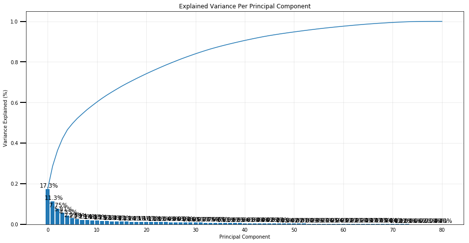

```python
hlp.scree_plot(pca)
```

```python
# Investigate the variance accounted for by each principal component.
cumvar = 0
for i, score in enumerate(pca.explained_variance_ratio_):
    cumvar += score
    print(f"Component number {i+1} explains {score * 100}% of the variance. Cumulative explained variance is {cumvar * 100}%.")
```

```
Component number 1 explains 17.341922144023126% of the variance. Cumulative explained variance is 17.341922144023126%.
Component number 2 explains 11.312051714819013% of the variance. Cumulative explained variance is 28.653973858842143%.
Component number 3 explains 7.7533929792973115% of the variance. Cumulative explained variance is 36.40736683813945%.
Component number 4 explains 5.819718211691337% of the variance. Cumulative explained variance is 42.22708504983079%.
Component number 5 explains 4.357084301396984% of the variance. Cumulative explained variance is 46.58416935122778%.
Component number 6 explains 2.9967539979755586% of the variance. Cumulative explained variance is 49.58092334920334%.
Component number 7 explains 2.59793982071756% of the variance. Cumulative explained variance is 52.178863169920895%.
Component number 8 explains 2.198775953712097% of the variance. Cumulative explained variance is 54.377639123632996%.
Component number 9 explains 2.1412541054717997% of the variance. Cumulative explained variance is 56.51889322910479%.
Component number 10 explains 1.9010893328349727% of the variance. Cumulative explained variance is 58.41998256193976%.
Component number 11 explains 1.8509768954594583% of the variance. Cumulative explained variance is 60.27095945739922%.
Component number 12 explains 1.7539458583287526% of the variance. Cumulative explained variance is 62.02490531572798%.
Component number 13 explains 1.6205360830266888% of the variance. Cumulative explained variance is 63.64544139875466%.
Component number 14 explains 1.5071489620885161% of the variance. Cumulative explained variance is 65.15259036084318%.
Component number 15 explains 1.4514235060381575% of the variance. Cumulative explained variance is 66.60401386688133%.
Component number 16 explains 1.4182530823961867% of the variance. Cumulative explained variance is 68.02226694927751%.
Component number 17 explains 1.3162907529178778% of the variance. Cumulative explained variance is 69.33855770219539%.
Component number 18 explains 1.247988409206499% of the variance. Cumulative explained variance is 70.58654611140189%.
Component number 19 explains 1.2349626474034443% of the variance. Cumulative explained variance is 71.82150875880534%.
Component number 20 explains 1.1866940437601448% of the variance. Cumulative explained variance is 73.00820280256548%.
Component number 21 explains 1.168369181453807% of the variance. Cumulative explained variance is 74.17657198401929%.
Component number 22 explains 1.1197603630909754% of the variance. Cumulative explained variance is 75.29633234711027%.
Component number 23 explains 1.0873792137346552% of the variance. Cumulative explained variance is 76.38371156084492%.
Component number 24 explains 1.0747966349215101% of the variance. Cumulative explained variance is 77.45850819576643%.
Component number 25 explains 1.0408165124454005% of the variance. Cumulative explained variance is 78.49932470821183%.
Component number 26 explains 0.9937555434566816% of the variance. Cumulative explained variance is 79.49308025166852%.
Component number 27 explains 0.9660838207369398% of the variance. Cumulative explained variance is 80.45916407240546%.
Component number 28 explains 0.9526888518129717% of the variance. Cumulative explained variance is 81.41185292421842%.
Component number 29 explains 0.9034517308941014% of the variance. Cumulative explained variance is 82.31530465511253%.
Component number 30 explains 0.8642679914208347% of the variance. Cumulative explained variance is 83.17957264653334%.
Component number 31 explains 0.8521439853914502% of the variance. Cumulative explained variance is 84.03171663192481%.
Component number 32 explains 0.8108648103507748% of the variance. Cumulative explained variance is 84.84258144227557%.
Component number 33 explains 0.7790587343514246% of the variance. Cumulative explained variance is 85.621640176627%.
Component number 34 explains 0.7503045363915168% of the variance. Cumulative explained variance is 86.37194471301852%.
Component number 35 explains 0.6825835436345233% of the variance. Cumulative explained variance is 87.05452825665304%.
Component number 36 explains 0.6573994723526946% of the variance. Cumulative explained variance is 87.71192772900574%.
Component number 37 explains 0.6195165987437489% of the variance. Cumulative explained variance is 88.33144432774948%.
Component number 38 explains 0.5956916673624059% of the variance. Cumulative explained variance is 88.9271359951119%.
Component number 39 explains 0.573140464260383% of the variance. Cumulative explained variance is 89.50027645937227%.
Component number 40 explains 0.5580702112267413% of the variance. Cumulative explained variance is 90.05834667059902%.
```

[output cut: 26 more lines]

```
Component number 67 explains 0.17384673403304132% of the variance. Cumulative explained variance is 98.85928126099068%.
Component number 68 explains 0.1702473387205974% of the variance. Cumulative explained variance is 99.02952859971128%.
Component number 69 explains 0.1549438522056585% of the variance. Cumulative explained variance is 99.18447245191693%.
Component number 70 explains 0.1472640255117236% of the variance. Cumulative explained variance is 99.33173647742866%.
Component number 71 explains 0.1404662257665944% of the variance. Cumulative explained variance is 99.47220270319525%.
Component number 72 explains 0.12245655525765177% of the variance. Cumulative explained variance is 99.59465925845291%.
Component number 73 explains 0.12230956767966235% of the variance. Cumulative explained variance is 99.71696882613257%.
Component number 74 explains 0.09742603584059768% of the variance. Cumulative explained variance is 99.81439486197317%.
Component number 75 explains 0.06761820947788942% of the variance. Cumulative explained variance is 99.88201307145106%.
Component number 76 explains 0.061209137241031934% of the variance. Cumulative explained variance is 99.94322220869209%.
Component number 77 explains 0.027222496986117846% of the variance. Cumulative explained variance is 99.9704447056782%.
Component number 78 explains 0.013427709822489553% of the variance. Cumulative explained variance is 99.9838724155007%.
Component number 79 explains 0.008783685057774243% of the variance. Cumulative explained variance is 99.99265610055848%.
Component number 80 explains 0.007343899441574621% of the variance. Cumulative explained variance is 100.00000000000004%.
Component number 81 explains 4.4008823542952175e-27% of the variance. Cumulative explained variance is 100.00000000000004%.
```

```python
# Re-apply PCA to the data while selecting for number of components to retain.

pca_40, azdias_40 = hlp.do_pca(40, azdias_scaled)
```

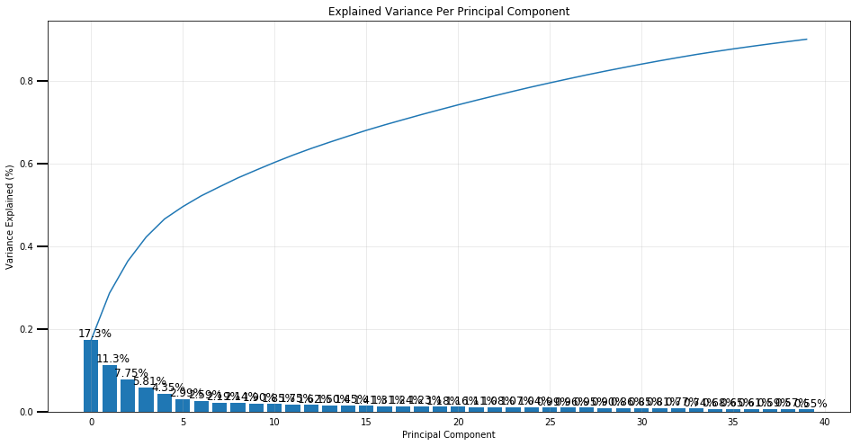

```python
hlp.scree_plot(pca_40)
```

### Discussion 2.2: Perform Dimensionality Reduction

Using scikit-learn's `PCA` we performed principal component analysis on the scaled demographics data. The number of components used to fit the model is equal to the number of features in the dataframe. We fitted the PCA model and obtained a scree plot of the result:

### Step 2.3: Interpret Principal Components

Now that we have our transformed principal components, it's a nice idea to check out the weight of each variable on the first few components to see if they can be interpreted in some fashion.

As a reminder, each principal component is a unit vector that points in the direction of highest variance (after accounting for the variance captured by earlier principal components). The further a weight is from zero, the more the principal component is in the direction of the corresponding feature. If two features have large weights of the same sign (both positive or both negative), then increases in one tend expect to be associated with increases in the other. To contrast, features with different signs can be expected to show a negative correlation: increases in one variable should result in a decrease in the other.

- To investigate the features, you should map each weight to their corresponding feature name, then sort the features according to weight. The most interesting features for each principal component, then, will be those at the beginning and end of the sorted list. Use the data dictionary document to help you understand these most prominent features, their relationships, and what a positive or negative value on the principal component might indicate.
- You should investigate and interpret feature associations from the first three principal components in this substep. To help facilitate this, you should write a function that you can call at any time to print the sorted list of feature weights, for the *i*-th principal component. This might come in handy in the next step of the project, when you interpret the tendencies of the discovered clusters.

```python
# Map weights for the first principal component to corresponding feature names
# and then print the linked values, sorted by weight.
# HINT: Try defining a function here or in a new cell that you can reuse in the
# other cells.
print("Feature weights for component number 1 \n")
weights_component_1 = hlp.get_feature_weights_by_component(azdias_final, pca, 1)
weights_component_1
```

```
Feature weights for component number 1
```

```
PLZ8_ANTG3               0.196107
CAMEO_DEUG_2015          0.191800
HH_EINKOMMEN_SCORE       0.191659
PLZ8_ANTG4               0.189276
CI_wealth                0.188670
PLZ8_BAUMAX              0.185326
ORTSGR_KLS9              0.167138
EWDICHTE                 0.165122
FINANZ_HAUSBAUER         0.158794
KBA05_ANTG4              0.136371
PLZ8_ANTG2               0.134170
ZABEOTYP                 0.128187
KBA05_ANTG3              0.123639
ARBEIT                   0.121780
ANZ_HAUSHALTE_AKTIV      0.121438
RELAT_AB                 0.114938
PJ_movement              0.109125
FINANZ_SPARER            0.107835
SEMIO_PFLICHT            0.077988
SEMIO_REL                0.073915
PJ_decade                0.067418
GEBAEUDETYP              0.066612
SEMIO_RAT                0.064830
W_KEIT_KIND_HH           0.062673
GFK_URLAUBERTYP          0.058141
SEMIO_TRADV              0.054197
SEMIO_MAT                0.053612
REGIOTYP                 0.052819
SEMIO_FAM                0.050828
FINANZ_UNAUFFAELLIGER    0.046740
                           ...
SEMIO_ERL               -0.043684
OST_WEST_KZ             -0.046440
SEMIO_LUST              -0.046854
FINANZTYP               -0.050542
MIN_GEBAEUDEJAHR        -0.051811
WOHNDAUER_2008          -0.055338
KBA13_ANZAHL_PKW        -0.064196
ONLINE_AFFINITAET       -0.066338
WOHNLAGE                -0.069273
FINANZ_VORSORGER        -0.078026
ALTERSKATEGORIE_GROB    -0.078083
ANZ_PERSONEN            -0.101021
GEBAEUDETYP_RASTER      -0.102361
LP_FAMILIE_FEIN         -0.103195
BALLRAUM                -0.104748
LP_FAMILIE_GROB         -0.105225
GREEN_AVANTGARDE        -0.109125
CI_life_stage           -0.109870
INNENSTADT              -0.137844
LP_LEBENSPHASE_GROB     -0.139165
PLZ8_GBZ                -0.144591
KONSUMNAEHE             -0.145532
LP_LEBENSPHASE_FEIN     -0.151957
KBA05_GBZ               -0.192136
FINANZ_MINIMALIST       -0.192798
KBA05_ANTG1             -0.193844
PLZ8_ANTG1              -0.196727
MOBI_REGIO              -0.203844
LP_STATUS_GROB          -0.212460
LP_STATUS_FEIN          -0.214357
Length: 81, dtype: float64
```

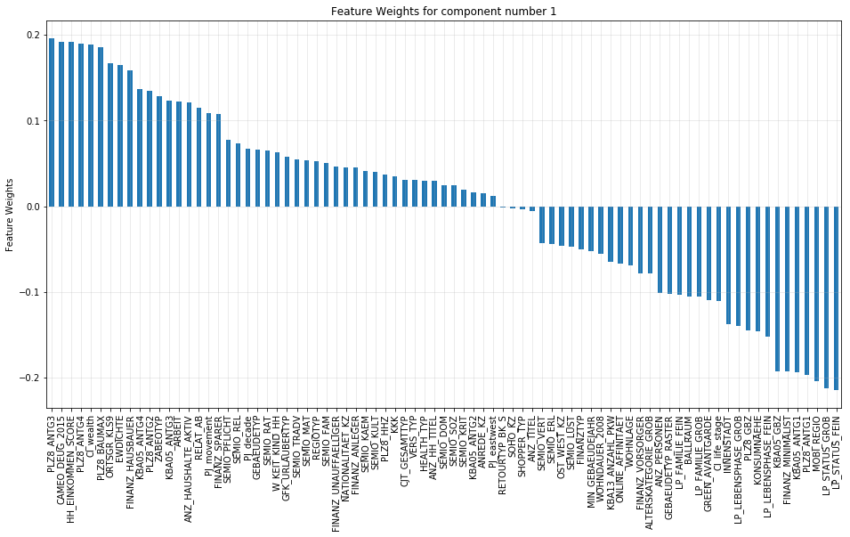

```python
hlp.plot_feature_weights_by_component(weights_component_1, 1)
```

```
Highest 3 weights are:

PLZ8_ANTG3            0.196107
CAMEO_DEUG_2015       0.191800
HH_EINKOMMEN_SCORE    0.191659
dtype: float64

lowest 3 weights are:

LP_STATUS_FEIN   -0.214357
LP_STATUS_GROB   -0.212460
MOBI_REGIO       -0.203844
dtype: float64
```

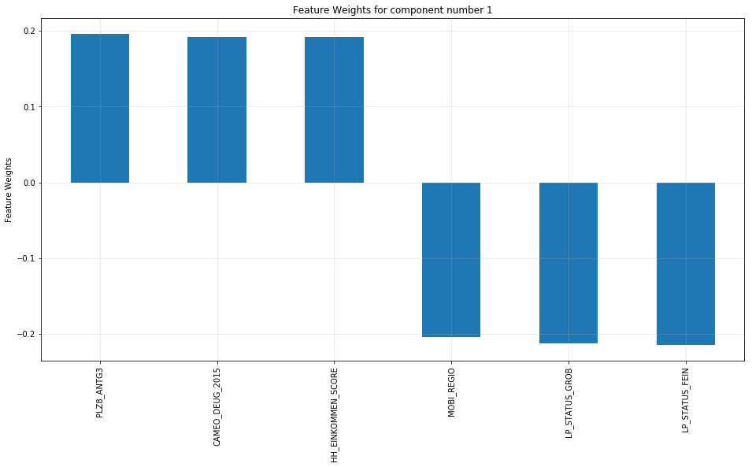

```python
hlp.get_interesting_features_by_components(azdias_final, pca, 1, 3)
```

### Interesting features for component 01:

```python
# Map weights for the second principal component to corresponding feature names
# and then print the linked values, sorted by weight.

print("Feature weights for component number 2 \n")
weights_component_2 = hlp.get_feature_weights_by_component(azdias_final, pca, 2)
weights_component_2
```

```
Feature weights for component number 2
```

```
ALTERSKATEGORIE_GROB     0.265234
FINANZ_VORSORGER         0.237905
SEMIO_ERL                0.223904
SEMIO_LUST               0.183052
RETOURTYP_BK_S           0.161779
W_KEIT_KIND_HH           0.119348
FINANZTYP                0.115333
SEMIO_KRIT               0.104919
SHOPPER_TYP              0.103048
FINANZ_MINIMALIST        0.098226
SEMIO_KAEM               0.090489
FINANZ_HAUSBAUER         0.086535
ANREDE_KZ                0.073309
WOHNDAUER_2008           0.059923
EWDICHTE                 0.059136
PLZ8_ANTG3               0.058710
ORTSGR_KLS9              0.058120
PLZ8_ANTG4               0.055187
SEMIO_DOM                0.054779
PLZ8_BAUMAX              0.051617
KBA05_ANTG4              0.045977
ARBEIT                   0.044705
CI_wealth                0.044610
RELAT_AB                 0.042238
ANZ_HAUSHALTE_AKTIV      0.040601
PLZ8_ANTG2               0.040474
CAMEO_DEUG_2015          0.039764
PJ_eastwest              0.031567
HH_EINKOMMEN_SCORE       0.026362
KBA05_ANTG3              0.024869
                           ...
WOHNLAGE                -0.039925
KBA05_ANTG1             -0.040209
GFK_URLAUBERTYP         -0.042136
KONSUMNAEHE             -0.043293
MOBI_REGIO              -0.045461
PLZ8_GBZ                -0.046435
INNENSTADT              -0.047237
LP_LEBENSPHASE_GROB     -0.048717
SEMIO_VERT              -0.049786
KBA05_GBZ               -0.053199
PLZ8_ANTG1              -0.057140
HEALTH_TYP              -0.061098
ANZ_PERSONEN            -0.069661
NATIONALITAET_KZ        -0.074295
LP_FAMILIE_FEIN         -0.079345
LP_FAMILIE_GROB         -0.080443
SEMIO_SOZ               -0.095400
CJT_GESAMTTYP           -0.129251
SEMIO_MAT               -0.161273
ONLINE_AFFINITAET       -0.162574
SEMIO_FAM               -0.177412
SEMIO_RAT               -0.181372
FINANZ_ANLEGER          -0.210726
SEMIO_KULT              -0.212041
FINANZ_UNAUFFAELLIGER   -0.230984
SEMIO_TRADV             -0.232646
SEMIO_PFLICHT           -0.236636
FINANZ_SPARER           -0.247932
PJ_decade               -0.249791
SEMIO_REL               -0.257592
Length: 81, dtype: float64
```

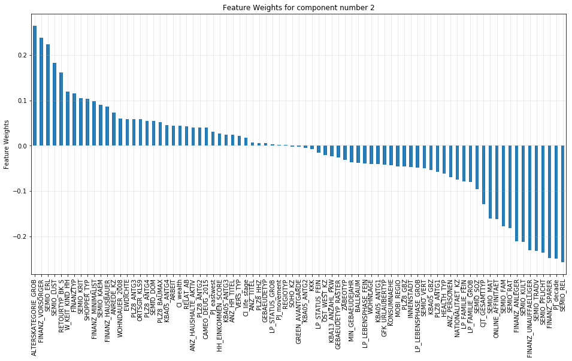

```python
hlp.plot_feature_weights_by_component(weights_component_2, 2)
```

```
Highest 3 weights are:

ALTERSKATEGORIE_GROB    0.265234
FINANZ_VORSORGER        0.237905
SEMIO_ERL               0.223904
dtype: float64

lowest 3 weights are:

SEMIO_REL       -0.257592
PJ_decade       -0.249791
FINANZ_SPARER   -0.247932
dtype: float64
```

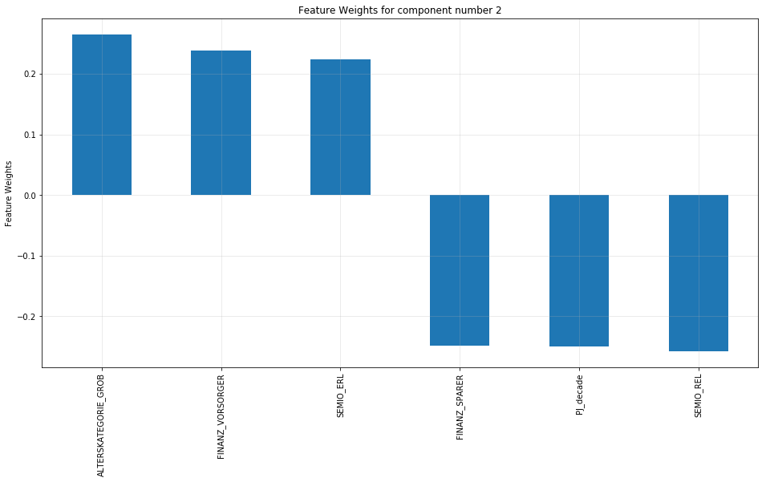

```python
hlp.get_interesting_features_by_components(azdias_final, pca, 2, 3)
```

### Interesting features for component 02:

```python
# Map weights for the third principal component to corresponding feature names
# and then print the linked values, sorted by weight.

print("Feature weights for component number 3 \n")
weights_component_3 = hlp.get_feature_weights_by_component(azdias_final, pca, 3)
weights_component_3
```

```
Feature weights for component number 3
```

```
SEMIO_VERT               0.338487
SEMIO_SOZ                0.261084
SEMIO_FAM                0.254568
SEMIO_KULT               0.241090
FINANZ_MINIMALIST        0.150725
FINANZTYP                0.115165
RETOURTYP_BK_S           0.098982
SEMIO_REL                0.084262
FINANZ_VORSORGER         0.083461
W_KEIT_KIND_HH           0.080047
SEMIO_MAT                0.064846
ALTERSKATEGORIE_GROB     0.060267
PLZ8_BAUMAX              0.052460
ORTSGR_KLS9              0.050324
GREEN_AVANTGARDE         0.050014
SEMIO_LUST               0.049445
PLZ8_ANTG4               0.049012
PLZ8_ANTG3               0.048347
EWDICHTE                 0.048298
LP_STATUS_GROB           0.038862
ARBEIT                   0.038266
RELAT_AB                 0.032902
PLZ8_ANTG2               0.031218
CAMEO_DEUG_2015          0.029648
CI_wealth                0.029292
WOHNDAUER_2008           0.027095
KBA05_ANTG4              0.026616
LP_STATUS_FEIN           0.023675
ANZ_HAUSHALTE_AKTIV      0.023649
ANZ_HH_TITEL             0.012294
                           ...
LP_FAMILIE_FEIN         -0.023437
KBA05_GBZ               -0.023590
WOHNLAGE                -0.023788
MOBI_REGIO              -0.024169
LP_FAMILIE_GROB         -0.025057
KBA13_ANZAHL_PKW        -0.025544
GEBAEUDETYP_RASTER      -0.032236
CJT_GESAMTTYP           -0.032928
BALLRAUM                -0.036440
KONSUMNAEHE             -0.039536
PLZ8_GBZ                -0.042610
INNENSTADT              -0.045641
ONLINE_AFFINITAET       -0.047321
PJ_movement             -0.050014
PLZ8_ANTG1              -0.050114
FINANZ_HAUSBAUER        -0.050497
ZABEOTYP                -0.060548
SEMIO_TRADV             -0.062027
SEMIO_PFLICHT           -0.062741
FINANZ_UNAUFFAELLIGER   -0.089945
FINANZ_SPARER           -0.091187
PJ_decade               -0.092813
SHOPPER_TYP             -0.122910
FINANZ_ANLEGER          -0.174800
SEMIO_ERL               -0.185444
SEMIO_RAT               -0.199463
SEMIO_KRIT              -0.271572
SEMIO_DOM               -0.306973
SEMIO_KAEM              -0.332653
ANREDE_KZ               -0.363624
Length: 81, dtype: float64
```

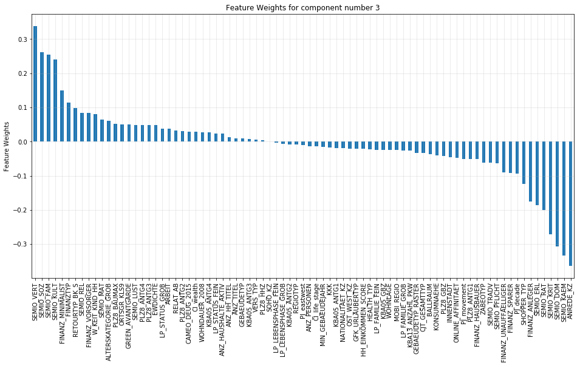

```python
hlp.plot_feature_weights_by_component(weights_component_3, 3)
```

```
Highest 3 weights are:

SEMIO_VERT    0.338487
SEMIO_SOZ     0.261084
SEMIO_FAM     0.254568
dtype: float64

lowest 3 weights are:

ANREDE_KZ    -0.363624
SEMIO_KAEM   -0.332653
SEMIO_DOM    -0.306973
dtype: float64
```

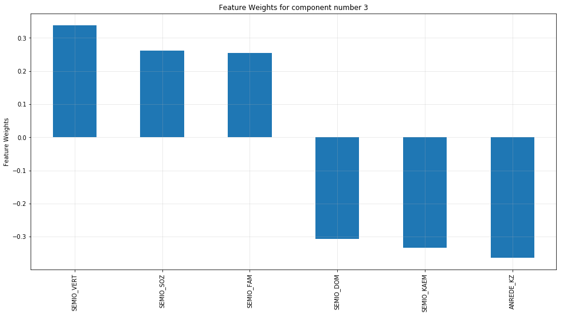

```python
hlp.get_interesting_features_by_components(azdias_final, pca, 3, 3)
```

### Interesting features for component 03:

**Positive weights**

**Negative weights**

### Discussion 2.3: Interpret Principal Components

Now that we have our fitted PCA model, we will explore the first three principal components and how they relate to features in the data. To accomplish this, for each component: we mapped each weight to their corresponding feature name, then sorted the features according to weight value. The most interesting features for each principal component are those at the beginning and end of the sorted list. For each component we investigated the first and last 3 features.

#### In the case of component 02:

The highest weights are given to the features `ALTERSKATEGORIE_GROB` (positive weight) and `SEMIO_REL` (negative weight). These two features represent Estimated age based on given name analysis and religiosity, respectively. Being at the two far ends of the weights spectrum indicates a negative correlation may present between the two.

#### In the case of component 03:

**Positive weights**

**Negative weights**

The highest weights are given to the features `SEMIO_VERT` (positive weight) and `ANREDE_KZ` (negative weight). These two features represent Personality typology, in this case being dreamful and gender, respectively. Being at the two far ends of the weights spectrum indicates a negative correlation may present between the two.

## Step 3: Clustering

### Step 3.1: Apply Clustering to General Population

You've assessed and cleaned the demographics data, then scaled and transformed them. Now, it's time to see how the data clusters in the principal components space. In this substep, you will apply k-means clustering to the dataset and use the average within-cluster distances from each point to their assigned cluster's centroid to decide on a number of clusters to keep.

- Use sklearn's KMeans class to perform k-means clustering on the PCA-transformed data.
- Then, compute the average difference from each point to its assigned cluster's center. **Hint**: The KMeans object's `.score()` method might be useful here, but note that in sklearn, scores tend to be defined so that larger is better. Try applying it to a small, toy dataset, or use an internet search to help your understanding.
- Perform the above two steps for a number of different cluster counts. You can then see how the average distance decreases with an increasing number of clusters. However, each additional cluster provides a smaller net benefit. Use this fact to select a final number of clusters in which to group the data. **Warning**: because of the large size of the dataset, it can take a long time for the algorithm to resolve. The more clusters to fit, the longer the algorithm will take. You should test for cluster counts through at least 10 clusters to get the full picture, but you shouldn't need to test for a number of clusters above about 30.
- Once you've selected a final number of clusters to use, re-fit a KMeans instance to perform the clustering operation. Make sure that you also obtain the cluster assignments for the general demographics data, since you'll be using them in the final Step 3.3.

```python
# Over a number of different cluster counts...
# run k-means clustering on the data and...
# compute the average within-cluster distances.

centers = [3, 6, 9, 12, 15, 18, 21, 24, 27, 30]
scores = []

for center in tqdm(centers):
    score = hlp.get_kmeans_score(azdias_40, center)
    scores.append(score)
```

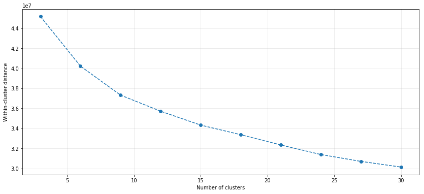

```python
# Investigate the change in within-cluster distance across number of clusters.
# HINT: Use matplotlib's plot function to visualize this relationship.
plt.figure(figsize=(14,6))
plt.plot(centers, scores, linestyle='--', marker='o', color='C0');
plt.xlabel('Number of clusters');
plt.ylabel('Within-cluster distance');
```

```python
# Re-fit the k-means model with the selected number of clusters and obtain
# cluster predictions for the general population demographics data.

kmeans_15 = KMeans(n_clusters=15, random_state=15).fit(azdias_40)
```

```python
demo_predictions = kmeans_15.predict(azdias_40)
demo_predictions
```

```
array([ 4, 10,  0, ..., 10, 14,  2], dtype=int32)
```

### Discussion 3.1: Apply Clustering to General Population

Now that we have the PCA-transformed dataset, we are going to perform clustering. We are going to use scikit-learn's `KMeans` to perform K-means clustering. The first question we need to answer is the k question, or how many centers we are going to chose we performing clustering.

To find a suitable k value, we fitted several KMeans models on the data and used the `.score()` method to compare them. This method simply tells us how coherent clusters are internally.

We plotted the number of clusters against the result of `.score()`. We are supposed to chose the k value at the elbow in the graph. But from the above chart we can see the elbow is not that easy to discern. The drop in the score value after k value of 15 is not as big as the drop in the score value before 15. We will choose 15 as the chosen number of clusters to fit our `KMeamns` model.

A new `KMeans` model with k value of 15 with fitted to our data. The cluster labels were produced and saved for use in the next step.

### Step 3.2: Apply All Steps to the Customer Data

Now that you have clusters and cluster centers for the general population, it's time to see how the customer data maps on to those clusters. Take care to not confuse this for re-fitting all of the models to the customer data. Instead, you're going to use the fits from the general population to clean, transform, and cluster the customer data. In the last step of the project, you will interpret how the general population fits apply to the customer data.

- Don't forget when loading in the customers data, that it is semicolon (`;`) delimited.
- Apply the same feature wrangling, selection, and engineering steps to the customer demographics using the `clean_data()` function you created earlier. (You can assume that the customer demographics data has similar meaning behind missing data patterns as the general demographics data.)
- Use the sklearn objects from the general demographics data, and apply their transformations to the customers data. That is, you should not be using a `.fit()` or `.fit_transform()` method to re-fit the old objects, nor should you be creating new sklearn objects! Carry the data through the feature scaling, PCA, and clustering steps, obtaining cluster assignments for all of the data in the customer demographics data.

```python
# Load in the customer demographics data.
customers = pd.read_csv("Udacity_CUSTOMERS_Subset.csv", sep=";")
```

```python
customers.head()
```

|  | AGER_TYP | ALTERSKATEGORIE_GROB | ANREDE_KZ | CJT_GESAMTTYP | FINANZ_MINIMALIST | FINANZ_SPARER | FINANZ_VORSORGER | FINANZ_ANLEGER | FINANZ_UNAUFFAELLIGER | FINANZ_HAUSBAUER | ... | PLZ8_ANTG1 | PLZ8_ANTG2 | PLZ8_ANTG3 | PLZ8_ANTG4 | PLZ8_BAUMAX | PLZ8_HHZ | PLZ8_GBZ | ARBEIT | ORTSGR_KLS9 | RELAT_AB |
| --- | --- | --- | --- | --- | --- | --- | --- | --- | --- | --- | --- | --- | --- | --- | --- | --- | --- | --- | --- | --- | --- |
| 0 | 2 | 4 | 1 | 5.0 | 5 | 1 | 5 | 1 | 2 | 2 | ... | 3.0 | 3.0 | 1.0 | 0.0 | 1.0 | 5.0 | 5.0 | 1.0 | 2.0 | 1.0 |
| 1 | -1 | 4 | 1 | NaN | 5 | 1 | 5 | 1 | 3 | 2 | ... | NaN | NaN | NaN | NaN | NaN | NaN | NaN | NaN | NaN | NaN |
| 2 | -1 | 4 | 2 | 2.0 | 5 | 1 | 5 | 1 | 4 | 4 | ... | 2.0 | 3.0 | 3.0 | 1.0 | 3.0 | 3.0 | 2.0 | 3.0 | 5.0 | 3.0 |
| 3 | 1 | 4 | 1 | 2.0 | 5 | 1 | 5 | 2 | 1 | 2 | ... | 3.0 | 2.0 | 1.0 | 0.0 | 1.0 | 3.0 | 4.0 | 1.0 | 3.0 | 1.0 |
| 4 | -1 | 3 | 1 | 6.0 | 3 | 1 | 4 | 4 | 5 | 2 | ... | 2.0 | 4.0 | 2.0 | 1.0 | 2.0 | 3.0 | 3.0 | 3.0 | 5.0 | 1.0 |

5 rows × 85 columns

```python
customers_clean = clean_data(customers, feat_info, 34)
```

```
Converting missing value codes to NaNs is COMPLETE

Cleaning is now COMPLETE
```

```python
customers_clean.shape
```

```
(139229, 81)
```

```python
# Apply preprocessing, feature transformation, and clustering from the general
# demographics onto the customer data, obtaining cluster predictions for the
# customer demographics data.
customers_imputed = imputer.transform(customers_clean)
customers_scaled = scaler.transform(customers_imputed)
customers_pca = pca_40.transform(customers_scaled)
```

```python
customers_predictions = kmeans_15.predict(customers_pca)
customers_predictions
```

```
array([ 9,  5,  3, ...,  9, 11, 11], dtype=int32)
```

### Step 3.3: Compare Customer Data to Demographics Data

At this point, you have clustered data based on demographics of the general population of Germany, and seen how the customer data for a mail-order sales company maps onto those demographic clusters. In this final substep, you will compare the two cluster distributions to see where the strongest customer base for the company is.

Consider the proportion of persons in each cluster for the general population, and the proportions for the customers. If we think the company's customer base to be universal, then the cluster assignment proportions should be fairly similar between the two. If there are only particular segments of the population that are interested in the company's products, then we should see a mismatch from one to the other. If there is a higher proportion of persons in a cluster for the customer data compared to the general population (e.g. 5% of persons are assigned to a cluster for the general population, but 15% of the customer data is closest to that cluster's centroid) then that suggests the people in that cluster to be a target audience for the company. On the other hand, the proportion of the data in a cluster being larger in the general population than the customer data (e.g. only 2% of customers closest to a population centroid that captures 6% of the data) suggests that group of persons to be outside of the target demographics.

Take a look at the following points in this step:

- Compute the proportion of data points in each cluster for the general population and the customer data. Visualizations will be useful here: both for the individual dataset proportions, but also to visualize the ratios in cluster representation between groups. Seaborn's [`countplot()`](https://seaborn.pydata.org/generated/seaborn.countplot.html) or [`barplot()`](https://seaborn.pydata.org/generated/seaborn.barplot.html) function could be handy.
  - Recall the analysis you performed in step 1.1.3 of the project, where you separated out certain data points from the dataset if they had more than a specified threshold of missing values. If you found that this group was qualitatively different from the main bulk of the data, you should treat this as an additional data cluster in this analysis. Make sure that you account for the number of data points in this subset, for both the general population and customer datasets, when making your computations!
- Which cluster or clusters are overrepresented in the customer dataset compared to the general population? Select at least one such cluster and infer what kind of people might be represented by that cluster. Use the principal component interpretations from step 2.3 or look at additional components to help you make this inference. Alternatively, you can **use the `.inverse_transform()` method of the PCA and StandardScaler objects to transform centroids back to the original data space and interpret the retrieved values directly.**
- Perform a similar investigation for the underrepresented clusters. Which cluster or clusters are underrepresented in the customer dataset compared to the general population, and what kinds of people are typified by these clusters?

```python
clusters_comparison = hlp.get_clusters_summary(demo_predictions, customers_predictions)
clusters_comparison
```

|  | clusters | counts | proportions | category |
| --- | --- | --- | --- | --- |
| 0 | 1 | 57080 | 0.073060 | population |
| 1 | 1 | 7507 | 0.053918 | customers |
| 2 | 2 | 51600 | 0.066045 | population |
| 3 | 2 | 3187 | 0.022890 | customers |
| 4 | 3 | 75648 | 0.096826 | population |
| 5 | 3 | 12532 | 0.090010 | customers |
| 6 | 4 | 58375 | 0.074717 | population |
| 7 | 4 | 13329 | 0.095734 | customers |
| 8 | 5 | 63608 | 0.081415 | population |
| 9 | 5 | 959 | 0.006888 | customers |
| 10 | 6 | 51769 | 0.066262 | population |
| 11 | 6 | 15520 | 0.111471 | customers |
| 12 | 7 | 39248 | 0.050236 | population |
| 13 | 7 | 3924 | 0.028184 | customers |
| 14 | 8 | 44398 | 0.056827 | population |
| 15 | 8 | 1664 | 0.011952 | customers |
| 16 | 9 | 2139 | 0.015363 | customers |
| 17 | 9 | 50680 | 0.064868 | population |
| 18 | 10 | 53804 | 0.068866 | population |
| 19 | 10 | 43650 | 0.313512 | customers |
| 20 | 11 | 822 | 0.005904 | customers |
| 21 | 11 | 55757 | 0.071366 | population |
| 22 | 12 | 19819 | 0.142348 | customers |
| 23 | 12 | 56971 | 0.072920 | population |
| 24 | 13 | 10384 | 0.074582 | customers |
| 25 | 13 | 55898 | 0.071547 | population |
| 26 | 14 | 2755 | 0.019788 | customers |
| 27 | 14 | 3196 | 0.004091 | population |
| 28 | 15 | 63248 | 0.080954 | population |
| 29 | 15 | 1038 | 0.007455 | customers |

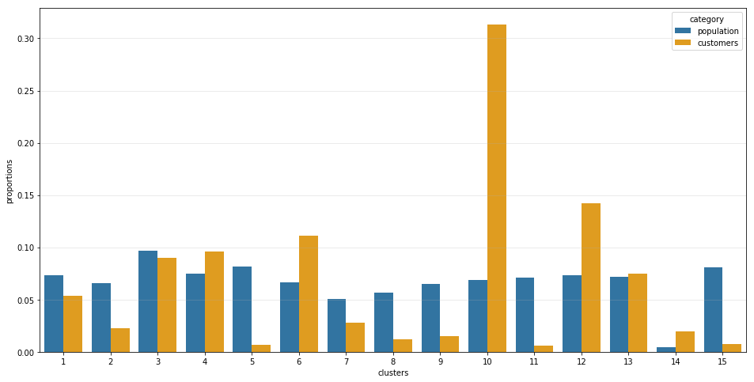

```python
# Compare the proportion of data in each cluster for the customer data to the
# proportion of data in each cluster for the general population.

fig, ax = plt.subplots(figsize=(16, 8))
sns.barplot(x="clusters", y="proportions", hue="category", data=clusters_comparison, palette=["C0", "orange"]);
```

#### Feature Dictionary

**Person-level features**

- `AGER_TYP`: Best-ager typology
- `ALTERSKATEGORIE_GROB`: Estimated age based on given name analysis
- `ANREDE_KZ`: Gender
- `CJT_GESAMTTYP`: Customer-Journey-Typology
- `FINANZ_MINIMALIST`, `FINANZ_SPARER`, `FINANZ_VORSORGER`, `FINANZ_ANLEGER`, `FINANZ_UNAUFFAELLIGER`, `FINANZ_HAUSBAUER`: Financial typology, for each dimension
- `FINANZTYP`: Most descriptive financial type for individual
- `GEBURTSJAHR`: Year of birth
- `GFK_URLAUBERTYP`: Vacation habits
- `GREEN_AVANTGARDE`: Membership in environmental sustainability as part of youth
- `HEALTH_TYP`: Health typology
- `LP_LEBENSPHASE_FEIN`: Life stage, fine scale
- `LP_LEBENSPHASE_GROB`: Life stage, rough scale
- `LP_FAMILIE_FEIN`: Family type, fine scale
- `LP_FAMILIE_GROB`: Family type, rough scale
- `LP_STATUS_FEIN`: Social status, fine scale
- `LP_STATUS_GROB`: Social status, rough scale
- `NATIONALITAET_KZ`: Nationality based on given name analysis
- `PRAEGENDE_JUGENDJAHRE`: Dominating movement of person's youth (avantgarde vs. mainstream; east vs. west)
- `RETOURTYP_BK_S`: Return type
- `SEMIO_SOZ`, `SEMIO_FAM`, `SEMIO_REL`, `SEMIO_MAT`, `SEMIO_VERT`, `SEMIO_LUST`, `SEMIO_ERL`, `SEMIO_KULT`, `SEMIO_RAT`, `SEMIO_KRIT`, `SEMIO_DOM`, `SEMIO_KAEM`, `SEMIO_PFLICHT`, `SEMIO_TRADV`: Personality typology, for each dimension
- `SHOPPER_TYP`: Shopper typology
- `SOHO_KZ`: Small office / home office flag
- `TITEL_KZ`: Academic title flag
- `VERS_TYP`: Insurance typology
- `ZABEOTYP`: Energy consumption typology

**Household-level features**

- `ALTER_HH`: Birthdate of head of household
- `ANZ_PERSONEN`: Number of adults in household
- `ANZ_TITEL`: Number of professional academic title holders in household
- `HH_EINKOMMEN_SCORE`: Estimated household net income
- `KK_KUNDENTYP`: Consumer pattern over past 12 months
- `W_KEIT_KIND_HH`: Likelihood of children in household
- `WOHNDAUER_2008`: Length of residence

**Building-level features**

- `ANZ_HAUSHALTE_AKTIV`: Number of households in the building
- `ANZ_HH_TITEL`: Number of professional academic title holders in building
- `GEBAEUDETYP`: Type of building (residential vs. commercial)
- `KONSUMNAEHE`: Distance from building to point of sale (PoS)
- `MIN_GEBAEUDEJAHR`: First year building was mentioned in the database
- `OST_WEST_KZ`: Building location via former East / West Germany (GDR / FRG)
- `WOHNLAGE`: Neighborhood quality (or rural flag)

**RR4 micro-cell features**

- `CAMEO_DEUG_2015`: German CAMEO: Wealth / Life Stage Typology, rough scale
- `CAMEO_DEU_2015`: German CAMEO: Wealth / Life Stage Typology, detailed scale
- `CAMEO_INTL_2015`: German CAMEO: Wealth / Life Stage Typology, mapped to international code

**RR3 micro-cell features**

- `KBA05_ANTG1`: Number of 1-2 family houses in the microcell
- `KBA05_ANTG2`: Number of 3-5 family houses in the microcell
- `KBA05_ANTG3`: Number of 6-10 family houses in the microcell
- `KBA05_ANTG4`: Number of 10+ family houses in the microcell
- `KBA05_BAUMAX`: Most common building type within the microcell
- `KBA05_GBZ`: Number of buildings in the microcell

**Postcode-level features**

- `BALLRAUM`: Distance to nearest urban center
- `EWDICHTE`: Density of households per square kilometer
- `INNENSTADT`: Distance to city center (downtown)

**RR1 region features**

- `GEBAEUDETYP_RASTER`: Ratio of residential to commercial activity
- `KKK`: Purchasing power in region
- `MOBI_REGIO`: Movement patterns
- `ONLINE_AFFINITAET`: Online affinity
- `REGIOTYP`: Neighborhood typology

**PLZ8 macro-cell features**

- `KBA13_ANZAHL_PKW`: Number of cars in the PLZ8 region
- `PLZ8_ANTG1`: Number of 1-2 family houses in the PLZ8 region
- `PLZ8_ANTG2`: Number of 3-5 family houses in the PLZ8 region
- `PLZ8_ANTG3`: Number of 6-10 family houses in the PLZ8 region
- `PLZ8_ANTG4`: Number of 10+ family houses in the PLZ8 region
- `PLZ8_BAUMAX`: Most common building type within the PLZ8 region
- `PLZ8_HHZ`: Number of households within the PLZ8 region
- `PLZ8_GBZ`: Number of buildings within the PLZ8 region

**Community-level features**

- `ARBEIT`: Share of unemployment in community
- `ORTSGR_KLS9`: Size of community
- `RELAT_AB`: Share of unemployment relative to county in which community is contained

```python
cluster_center_10 = kmeans_15.cluster_centers_[9]
cluster_center_10
```

```
array([ -4.13545240e+00,   3.12889429e-01,   2.81558654e+00,
         1.54043677e+00,  -1.95105126e+00,   1.67100753e-01,
        -8.58938329e-02,  -3.57744501e-04,  -6.10004832e-02,
        -7.66306162e-02,  -1.93902851e-01,  -1.33360356e-02,
         1.93672327e-01,   8.29602414e-02,  -3.90452522e-01,
         2.39470210e-01,  -2.99834348e-01,   2.13886885e-01,
        -4.39846920e-02,  -3.17034716e-02,   1.10011973e-02,
        -1.27680522e-03,  -8.51044376e-02,  -2.18728371e-01,
         7.05558028e-02,   3.19760356e-02,   7.75472884e-02,
        -1.33139316e-01,   5.49732710e-02,  -3.42341817e-02,
        -1.23295055e-01,   2.78448668e-02,  -1.02151753e-01,
        -7.17117553e-02,   2.82697397e-02,   2.73017735e-02,
         1.58256218e-01,   1.86371367e-01,   4.25911431e-02,
        -9.12344532e-02])
```

```python
cluster_10 = scaler.inverse_transform(pca_40.inverse_transform(cluster_center_10))
customers_cluster_10 = pd.Series(cluster_10, index = customers_clean.columns)
```

```python
# use most interesting features from the first 2 principal components
interesting_features = ["PLZ8_ANTG3",
                        "CAMEO_DEUG_2015",
                        "HH_EINKOMMEN_SCORE",
                        "MOBI_REGIO",
                        "LP_STATUS_FEIN",
                        "LP_STATUS_GROB",
                        "ALTERSKATEGORIE_GROB",
                        "FINANZ_VORSORGER",
                        "SEMIO_ERL",
                        "SEMIO_REL",
                        "PJ_decade",
                        "FINANZ_SPARER"]
```

```python
# What kinds of people are part of a cluster that is overrepresented in the
# customer data compared to the general population?

with pd.option_context('display.max_rows', None):
    print(customers_cluster_10[interesting_features].round())
```

```
PLZ8_ANTG3               1.0
CAMEO_DEUG_2015          4.0
HH_EINKOMMEN_SCORE       2.0
MOBI_REGIO               4.0
LP_STATUS_FEIN           9.0
LP_STATUS_GROB           5.0
ALTERSKATEGORIE_GROB     3.0
FINANZ_VORSORGER         4.0
SEMIO_ERL                4.0
SEMIO_REL                4.0
PJ_decade               68.0
FINANZ_SPARER            2.0
dtype: float64
```

#### Most important features and their values for cluster center no. 10

**According to first principal component:**

- `PLZ8_ANTG3`: **1** Number of 6-10 family houses in the PLZ8 region ---> lower share of 6-10 family homes
- `CAMEO_DEUG_2015`: **4** Wealth / Life Stage Typology, rough scale ---> consumption-oriented middleclass
- `HH_EINKOMMEN_SCORE`: **2** Estimated household net income ---> very high income
- `MOBI_REGIO`: **4** Movement patterns ---> low movement
- `LP_STATUS_FEIN`: **9** Social status, fine scale ---> houseowners
- `LP_STATUS_GROB`: **5** Social status, rough scale ---> Top earners

**According to second principal component:**

- `ALTERSKATEGORIE_GROB`: **3** Estimated age based on given name analysis ---> 46 - 60 years old
- `FINANZ_VORSORGER`: **4** Financial typology, be prepared ---> low
- `SEMIO_ERL`: **4** Personality typology, event-oriented ---> average affinity
- `SEMIO_REL`: **4** Personality typology, religious ---> average affinity
- `PJ_decade`: **68** Decade ---> Late sexties
- `FINANZ_SPARER`: **2** Financial typology, money-saver ---> high

```python
cluster_center_05 = kmeans_15.cluster_centers_[4]
cluster_center_05
```

```
array([  5.15355182e+00,  -1.91166576e+00,  -2.42333365e+00,
         7.46220732e-01,  -3.21682444e-01,   3.59233934e-01,
         2.68961901e-02,  -2.19710796e-01,  -2.79515337e-01,
         5.00408120e-01,  -2.42511950e-01,  -4.21935495e-01,
         1.24812485e-01,  -3.10719970e-01,   3.15911896e-02,
         2.00975564e-01,  -6.97234498e-02,   1.76536562e-01,
        -1.76017796e-02,  -5.68653133e-02,  -8.72174085e-02,
        -4.61041114e-02,   3.36238797e-02,  -3.30647820e-02,
        -3.41920582e-02,  -7.18847574e-02,   1.09574465e-02,
        -6.75537469e-03,   1.33084288e-01,   1.52637889e-01,
         8.80419250e-02,  -1.52309274e-01,   5.00002533e-02,
         5.74834692e-02,  -6.10727887e-02,  -1.48014280e-01,
         7.24779944e-02,   1.19647873e-01,  -8.82776589e-04,
        -9.15262183e-02])
```

```python
cluster_05 = scaler.inverse_transform(pca_40.inverse_transform(cluster_center_05))
customers_cluster_05 = pd.Series(cluster_05, index = customers_clean.columns)
```

```python
# What kinds of people are part of a cluster that is underrepresented in the
# customer data compared to the general population?

with pd.option_context('display.max_rows', None):
    print(customers_cluster_05[interesting_features].round())
```

```
PLZ8_ANTG3               3.0
CAMEO_DEUG_2015          8.0
HH_EINKOMMEN_SCORE       6.0
MOBI_REGIO               2.0
LP_STATUS_FEIN           2.0
LP_STATUS_GROB           1.0
ALTERSKATEGORIE_GROB     2.0
FINANZ_VORSORGER         2.0
SEMIO_ERL                4.0
SEMIO_REL                6.0
PJ_decade               88.0
FINANZ_SPARER            4.0
dtype: float64
```

#### Most important features and their values for cluster center no. 05

**According to first principal component:**

- `PLZ8_ANTG3`: **3** Number of 6-10 family houses in the PLZ8 region ---> high share of 6-10 family homes
- `CAMEO_DEUG_2015`: **8** Wealth / Life Stage Typology, rough scale ---> working class
- `HH_EINKOMMEN_SCORE`: **6** Estimated household net income ---> very low income
- `MOBI_REGIO`: **2** Movement patterns ---> high movement
- `LP_STATUS_FEIN`: **2** Social status, fine scale ---> orientation-seeking low-income earners
- `LP_STATUS_GROB`: **1** Social status, rough scale ---> low-income earners (maps to 1-2 in fine scale)

**According to second principal component:**

- `ALTERSKATEGORIE_GROB`: **2** Estimated age based on given name analysis ---> 30 - 45 years old
- `FINANZ_VORSORGER`: **2** Financial typology, be prepared ---> high
- `SEMIO_ERL`: **4** Personality typology, event-oriented ---> average high affinity
- `SEMIO_REL`: **6** Personality typology, religious ---> very low affinity
- `PJ_decade`: **88** Decade ---> Late 80s - early 90s
- `FINANZ_SPARER`: **4** Financial typology, money-saver ---> low

### Discussion 3.3: Compare Customer Data to Demographics Data

We now have a clustered data based on demographics of the general population of Germany. We now need to see how the customers data maps to the same clusters. The customers data was loaded, processed, and cleaned in order to perform scaling and PCA. The customers data was transformed using the same models that were used to transform the demographics data, no new objects were created. We then performed clustering on the transformed data using the same KMeans model that was used for the demographics dataset. Cluster labels for the customers data were produced and saved.

The proportion of data points in each cluster for the general population and the customer data were calculated. The computed proportions for the demographics data and the customers data were plotted side to side using clustered bar chart. This helps in observing the different ratios in proportions for each cluster between the two datasets.

From the figure comparing the proportions we can find that:

- For the population data, we can see that the proportion of clusters doesn't change much between one cluster and another.
- For the customers data, we can see that the proportion of clusters changes drastically with some clusters having a very high proportions and others very low.
- Cluster number 10 has the highest proportion in the customers data.
- The cluster 10 has a much higher proportion in the customers data than its proportion in the population. This could indicate that people in this segment are the target audience for the company.
- Clusters number 05, 11, and 15 are the ones with the lowest proportions in the customers data. But cluster 05 corresponds to a higher segment according to the population data.

We are going now to investigate segment **10** which represent the target audience of the company and segment **05** which is an underrepresented segment. In order to do that we need to reverse the scaling and PCA operations that were performed on the data. After that we will use our the most interesting features from the PCA analysis to find out what segment of people each cluster represent.

The above traits in the segment makes it a great target audience for a mail-ordering company.

**Segment 05**: Those are orientation-seeking working class with very low income. The estimated age fro this segment is 30 - 45 years old. People in the segment have higher share of multiple-family houses and they are almost always moving. They are not the kind that saves money.

The above traits in the segment don't make it a good candidate as target audience for a mail-ordering company.

In my opinion, the company is doing well by targeting and focusing on the people in segment **10**. They have a suitable traits to make them a great target audience for a mail-order company.

> Congratulations on making it this far in the project! Before you finish, make sure to check through the entire notebook from top to bottom to make sure that your analysis follows a logical flow and all of your findings are documented in **Discussion** cells. Once you've checked over all of your work, you should export the notebook as an HTML document to submit for evaluation. You can do this from the menu, navigating to **File -> Download as -> HTML (.html)**. You will submit both that document and this notebook for your project submission.